# Разработка моделей, предсказывающих уровень удовлетворённости работой и увольнения сотрудников.

## Описание проекта

### Задачи проекта

1. Построоение модели, которая сможет предсказать уровень удовлетворённости сотрудника на основе данных заказчика.
2. Построоение модели, которая сможет на основе данных заказчика и предсказанным уровнем удовлетворённости сотрудника предсказать то, что сотрудник уволится из компании.

### Этапы работы

1. **Загрузка библиотек, создание констант**
2. **Написание необходимых функций и классов**
3. **Задача 1: Предсказание уровня удовлетворённости сотрудника**
   1. **Загрузка данных, иучение общей информации о датафрейме, преобразование названий столбцов**
   2. **Предобработка данных:**
      - обработатка дубликатов
      - обработка пропущенных значений
      - проверка датафреймов на соответствие друг с другом
   3. **Исследовательский анализ данных**
   4. **Корреляционный анализ данных**
   5. **Созание пайплайна. Подбор параметров. Выбор лучшей модели**
   6. **Анализ важности признаков:**
      - оценка важность признаков для лучшей модели и построение графика важности с помощью метода SHAP
      - выводы о значимости признаков
   7. **Подведение итогов**
4. **Задача 2: Предсказание увольнения сотрудника из компании**
   1. **Загрузка данных, иучение общей информации о датафрейме, преобразование названий столбцов**
   2. **Предобработка данных:**
      - обработатка дубликатов
      - обработка пропущенных значений
      - проверка датафреймов на соответствие друг другу
   3. **Исследовательский анализ данных, включающий следующие пункты:**
      - статистический анализ всех признаков
      - проверка на вбросы, необычное распределение количественных признаков или другие особенности
      - составление портрета «уволившегося сотрудника»
      - визуализация и сравнение распределения признака job_satisfaction_rate для ушедших и оставшихся сотрудников
   4. **Корреляционный анализ. Устранение мультиколлинеарности**
   5. **Добавление нового входного признака job_satisfaction_rate в датафрейм**
   6. **Созание пайплайна. Подбор параметров. Выбор лучшей модели**
   7. **Анализ важности признаков:**
      - оценка важность признаков для лучшей модели и построение графика важности с помощью метода SHAP
      - выводы о значимости признаков
   8. **Подведение итогов**
5. **Общий вывод**

### Данные для исследования

- id — уникальный идентификатор сотрудника
- dept — отдел, в котором работает сотрудник
- level — уровень занимаемой должности
- workload — уровень загруженности сотрудника
- employment_years — длительность работы в компании (в годах)
- last_year_promo — показывает, было ли повышение за последний год
- last_year_violations — показывает, нарушал ли сотрудник трудовой договор за последний год
- supervisor_evaluation — оценка качества работы сотрудника, которую дал руководитель
- salary — ежемесячная зарплата сотрудника
- job_satisfaction_rate — уровень удовлетворённости сотрудника работой в компании, целевой признак

## Загрузка библиотек, установка дефолтных настроек, создание констант

### Загрузка библиотек

```python
# !pip uninstall numba --yes -q
# !pip install numba --upgrade -q

# !pip uninstall statsmodels --yes -q
# !pip install statsmodels --upgrade -q

# !pip uninstall numpy --yes -q
# !pip install numpy==1.24.2 -q

# !pip install matplotlib --upgrade -q
# !pip install seaborn --upgrade -q
# !pip install scikit-learn --upgrade -q

# !pip install phik -q
# !pip install optuna -q
# !pip install shap -q
# !pip install imbalanced-learn -q
# !pip install category_encoders --upgrade -q
# !pip install tensorflow --upgrade -q
# !pip install joblib --upgrade -q
# !pip install streamlit --upgrade -q
# !pip install torch --upgrade -q
```

```python
# Основные библиотеки
import pandas as pd
import numpy as np
from matplotlib import pyplot as plt
import seaborn as sns

# Билиотека для проведения статистических тестов
from scipy import stats as st

# Библиотека для построения корреляционной матрицы
import phik

# Библиотека и отдельные её модули для оптимизации параметров пайплайна
import optuna
from optuna.samplers import TPESampler
from optuna.pruners import MedianPruner
from optuna.integration.sklearn import OptunaSearchCV
from optuna.integration import CatBoostPruningCallback

# Импорт модулей для семплирования и для создания пайплайна
from imblearn.under_sampling import RandomUnderSampler
from imblearn.over_sampling import ADASYN, SMOTE
from imblearn.combine import SMOTETomek
from imblearn.pipeline import Pipeline as ImbPipeline

# Импорт модуля для разбивки данных на тренировочную и тестовую выборки
from sklearn.model_selection import train_test_split, KFold, StratifiedKFold

# Импорт модулей для кодирования и масштабирования
from sklearn.preprocessing import (LabelEncoder,
                                   OneHotEncoder,
                                   OrdinalEncoder,
                                   StandardScaler,
                                   MinMaxScaler,
                                   RobustScaler,
                                   FunctionTransformer)

# Импорт моделей машинного обучения
from sklearn.linear_model import LogisticRegression, LinearRegression, Ridge
from sklearn.neighbors import KNeighborsClassifier, KNeighborsRegressor
from sklearn.tree import DecisionTreeClassifier, DecisionTreeRegressor
from sklearn.svm import SVC
from sklearn.ensemble import RandomForestClassifier, RandomForestRegressor

# Импорт модулей для создания пайплайна
from sklearn.compose import (ColumnTransformer,
                             make_column_selector)

# Импорт модуля для работы с пропусками
from sklearn.impute import SimpleImputer, KNNImputer

# Импорт модуля для автоподбора гиперпараметров
from sklearn.model_selection import (GridSearchCV,
                                     RandomizedSearchCV,
                                     cross_val_score)

# Импорт метрик
from sklearn.metrics import (roc_auc_score,
                             accuracy_score,
                             f1_score,
                             precision_score,
                             recall_score,
                             confusion_matrix,
                             roc_curve,
                             mean_squared_error,
                             mean_absolute_error,
                             make_scorer,
                             auc)

# Модули используются для создания класса-пустышки для сэмплера
from sklearn.base import BaseEstimator, TransformerMixin

# Импорт дополнительного модуля для кодирования категориальных признаков
from category_encoders import TargetEncoder

# Импорт модулей tensorflow для создания embedding-кодировщика
import tensorflow as tf
from tensorflow.keras.layers import Input, Embedding, Flatten
from tensorflow.keras.models import Model

# Импорт модулей torch для создания embedding-кодировщика
import torch.nn as nn
import torch.optim as optim

# Импорт модулей из catboost
from catboost import (CatBoostClassifier,
                      CatBoostRegressor,
                      Pool,
                      cv)

# Импорт библиотеки для экспотрта пайплайнов и shap-значений
from joblib import dump

# Библиотека для интерпретации моделей
import shap
shap.initjs()
```

### Установка дефолтных настроек

```python
# Убираем необязательные предупреждения
import warnings
warnings.filterwarnings('ignore')

# Настраиваем полное отображение всех строк таблицы
pd.set_option('display.max_rows', 100)
pd.set_option('display.max_columns', 100)

# Задаём стандартне параметры для графиков
plt.rcParams['figure.figsize'] = (8, 3)
plt.rcParams.update({'font.size':'12'})

# Скрываем журнал с триалами
optuna.logging.set_verbosity(optuna.logging.WARNING)
```

### Создание констант

```python
# Создание констант
RANDOM_STATE = 38
```

## Функция для предобработки и анализа данных

### Функция для вывода распределения категориального признака

```python
def show_cat_feature(df, feature,
                     feature_name='',
                     cut_count_to_barplot=5):
    '''
        Строит круговую диаграмму или барплот для категориального признака.
        Показывает статистические параметры.

        Args:
            df (pandas.DataFrame) - датафрейм, в котором находится признак
            feature (str) - название признака
            feature_name (str, optional) - имя признака для подписи графика default feature_name=feature
            cut_count_to_barplot (int, optional) - минимальное количество категорий для построения барплота
                default cut_count_to_barplot=5
    '''

    # Ставим дефолтное название признака для подписи графика
    if feature_name == '':
        feature_name = feature

    # Создадим сводную таблцу для построения гистограммы или барплота
    pivot = df.pivot_table(index=feature, values='id', aggfunc='count')
    pivot.columns = ['customers']
    pivot = pivot.sort_values(by='customers')

    # Строим круговую диаграмму, если категорий меньше 5
    if len(pivot) < 5:
        # Создаём фигуру и ось
        fig, ax = plt.subplots()
        # Подписываем диаграмму
        ax.set_title(feature_name, fontsize=11)
        # Отрисовываем диаграмму
        ax.pie(pivot['customers'],
               labels=pivot.index,
               autopct='%1.2f%%',
               explode=([0.03] * len(pivot)))

    # Строим барплот, если категорий больше или равно 5
    else:
        # Создаём фигуру и оси
        fig, ax = plt.subplots(figsize=(6, 3))
        # Устанавливаем размер шрифта
        plt.rcParams.update({'font.size': 9})
        # Наносим сетку, подписываем оси
        ax.grid(axis='x')
        ax.set(title=feature_name,
               xlabel='количество сотрудников')
        # Отрисосываем графики
        ax.barh(pivot.index, pivot['customers'], linewidth=1.0, edgecolor='k', height=0.7)

    # Выводим график на экран
    plt.show()
```

### Функция для вывода гистограммы распределения количественного признака

```python
def show_num_feature(df, feature,
                     feature_name='',
                     bins=100,
                     boxplot_flag=True,
                     describe_flag=True):
    '''
        Строит гистограмму распределения и ящик с усами для количественного признака.
        Показывает статистические параметры.

        Args:
            df (pandas.DataFrame) - датафрейм, в котором находится признак
            feature (str) - название признака
            feature_name (str, optional) - имя признака для подписи графика default feature_name=feature
            bins (int, optional) - количество корзин на гистограмме default bins=100
            boxplot_flag (bool, optional) - показывать ящик с усами default boxplot_flag=True
            describe_flag (bool, optional) - показывать ящик с усами default describe_flag=True
    '''

    # Устанавливаем размер шрифта
    plt.rcParams.update({'font.size': 9})

    # Ставим дефолтное название признака для подписи графика
    if feature_name == '':
        feature_name = feature

    # Задаём фигуру и оси
    if boxplot_flag:
        fig, axs = plt.subplots(2, 1, figsize=(8, 5))
        ax_1 = axs[0]
        ax_2 = axs[1]
    else:
        fig, ax_1 = plt.subplots(1, 1, figsize=(8, 3))

    # Отрисовываем гистограмму
    ax_1.set_title(f'Гистограмма распределения для признака: {feature_name}', fontsize=11)
    ax_1.set_xlabel(f'{feature_name}')
    ax_1.set_ylabel('количество сотрудников', fontsize=9)
    ax_1.grid()
    ax_1.hist(df[feature], bins=bins, linewidth=1.0, edgecolor='k')

    # Отрисовываем ящик с усами, если стоит флаг
    if boxplot_flag:
        ax_2.set_title(f'Ящик с усами для признака: {feature_name}', fontsize=9)
        ax_2.set_xlabel(f'{feature_name}', fontsize=9)
        ax_2.grid()
        ax_2.boxplot(df[feature], vert=False)

    # Добавляем строчку, что бы не перекрывались подписи осей
    plt.tight_layout(pad=2.0)

    # Выводим график на экран
    plt.show()

    # Смотрим статистические параметры
    if boxplot_flag:
        display(pd.DataFrame(df[feature].describe()))
```

### Функция для анализа портреты уволившегося сотрудника

```python
def show_pivot(df, feature, title):
    '''
        Строит сводную таблицу и график barplot,
        для демонстрации зависимости процента увольнений от входного признака.

        Args:
            df (pandas.DataFrame) - датафрейм, в котором находится признак
            feature (str) - название признака
            title (str) - название итогового графика
    '''

    pivot = df.pivot_table(index=feature, columns='quit', values='id', aggfunc='count')
    pivot.index = pivot.index.astype('str')
    pivot.columns.name = ''
    pivot['all'] = pivot['yes'] + pivot['no']
    pivot['ratio'] = round(pivot['yes'] / pivot['all'] *100, 2)
    pivot = pivot.sort_values(by='ratio', ascending=False)

    plt.rcParams['figure.figsize'] = (6, 3)
    plt.rcParams.update({'font.size': 9})

    sns.barplot(pivot, x='ratio', y=feature, hue='ratio')
    plt.title(title)
    plt.xlabel('процент уволившихся')
    plt.ylabel('')

    # Настраиваем отображение легенды вне графика, меняем порядок меток на такой же, как на графике
    handles, labels = plt.gca().get_legend_handles_labels()
    plt.legend(reversed(handles), reversed(labels), title='ratio',bbox_to_anchor=(1, 1))

    plt.show()

    display(pivot)
```

## Классы для создания пайпланна, поиска параметров для моделей sclearn

### Класс для создания семплера-пустышки

```python
'''
    Создаём класс-пустышку для семплера.
    Нужен для того, что бы сэмплер не выдавал ошибке при попытке вызвать fit и predict,
    при значении paththrough.
'''
class Passthrough(BaseEstimator, TransformerMixin):
    def fit(self, X, y=None):
        return self

    def transform(self, X, y=None):
        return X
```

### Класс для создания embedding-кодировщика

```python
'''
    Нуден для того что бы можно было кодировать категориальные признаки
    по технологии embedding, с которой хорошо работают модели градиентного бустинга
'''
class EmbeddingEncoder(BaseEstimator, TransformerMixin):
    def __init__(self, embedding_dim=2, handle_unknown='ignore', random_state=None):
        self.embedding_dim = embedding_dim
        self.handle_unknown = handle_unknown
        self.random_state = random_state
        # Словарь уникальных значений категорий
        self.embeddings_ = {}
        # Словарь моделей встраиваний
        self.models_ = {}
        # Подавляем вывод журнала
        tf.get_logger().setLevel('ERROR')

        if random_state is not None:
            np.random.seed(random_state)
            tf.random.set_seed(random_state)

    def fit(self, X, y=None):
        # Обучение моделей встраиваний для каждого столбца
        original_log_level = tf.get_logger().level

        # Проходим по каждому столбцу данных
        for i, col in enumerate(X.T):
            # Находим и сохраняем уникальные значения в столбце
            unique_vals = np.unique(col)
            self.embeddings_[i] = unique_vals
            # Входной слой для модели
            input_layer = Input(shape=(1,))
            # Слой встраивания
            embedding_layer = Embedding(input_dim=len(unique_vals) + 1, output_dim=self.embedding_dim, input_length=1)(input_layer)
            # Развертывание вектора встраивания в плоский массив
            flatten_layer = Flatten()(embedding_layer)
            # Создаем, компилируем и сохраняем модель для текущего столбца
            model = Model(inputs=input_layer, outputs=flatten_layer)
            model.compile(optimizer='rmsprop', loss='mse')
            self.models_[i] = model
        # Восстанавливаем оригинальный уровень логирования TensorFlow
        tf.get_logger().setLevel(original_log_level)
        return self

    def transform(self, X):
        # Преобразование данных с использованием обученных моделей встраиваний.
        original_log_level = tf.get_logger().level

        # Список для хранения преобразованных данных
        X_transformed = []
        # Проходим по каждому столбцу данных
        for i, col in enumerate(X.T):
            # Получаем модель для текущего столбца
            model = self.models_[i]

            # Список для хранения индексов категорий
            col_indices = []
            # Преобразуем каждое значение в столбце в индекс
            for val in col:
                if val in self.embeddings_[i]:
                    col_indices.append(np.where(self.embeddings_[i] == val)[0][0])
                else:
                    # Не забываем про индекс для неизвестной категории
                    if self.handle_unknown == 'ignore':
                        col_indices.append(len(self.embeddings_[i]))
                    else:
                        raise ValueError(f"Unknown category '{val}' encountered in column {i}.")

            # Преобразуем список индексов в массив
            col_indices = np.array(col_indices)
            # Получаем встраивания для индексов
            col_embedded = model.predict(col_indices, verbose=0)
            # Добавляем встраивания в список
            X_transformed.append(col_embedded)

        # Возвращаем преобразованные данные как один массив
        return np.hstack(X_transformed)


    def get_feature_names_out(self, input_features=None):
        # Формирование списка имен новых признаков после встраивания
        feature_names = []
        for i in range(len(self.embeddings_)):
            for dim in range(self.embedding_dim):
                feature_names.append(f"col_{i}_dim_{dim}")
        return np.array(feature_names)
```

### Класс для создания метрики

```python
class MetricSmape:
    def __init__(self):
        self.smape = make_scorer(self.make_smape, greater_is_better=self.is_max_optimal())


    # Метод для создания метрики и последующего её использования для рассчётов
    def make_smape(self, y_true, y_pred, weight=None):
        if len(y_pred.shape) == 1:
            y_pred = self.remake_pred_array(y_pred)

        smape = self.custom_logloss_metric(y_true, y_pred)

        return np.mean(smape)


    # Метод нужен потому что разные модели отправляют данные в разных форматах
    def remake_pred_array(self, pred_array):
        new_pred_array = []
        for y in pred_array:
            new_pred_array.append([y])
        new_pred_array = np.asarray(new_pred_array)

        return new_pred_array


    # Метод, чтобы использовать в качестве eval_metric в catbost
    def evaluate(self, approxes, target, weight):
        approx = approxes[0]
        assert len(target) == len(approx)

        if weight is None:
            weight = np.ones(len(target))

        smape = self.custom_logloss_metric(approx, target)

        # Возвращаем кортеж (сумма ошибок, сумма весов)
        weighted_smape = np.sum(weight * smape) / np.sum(weight)

        return np.sum(weight * smape), np.sum(weight)


    # Метод для подсчёта метрики, используется для catboost как loss_function
    def custom_logloss_metric(self, y_true, y_pred):
        error = np.abs(y_true - y_pred)
        scale = (np.abs(y_true) + np.abs(y_pred)) / 2
        smape = error / scale * 100
        return smape


    # Метод для подсчёта производных, используется для catboost как loss_function
    def calc_ders_range(self, approxes, targets, weights):
        ders = []
        for approx, target in zip(approxes, targets):
            scale = (np.abs(target) + np.abs(approx)) / 2

            # Первая производная
            numerator = 2 * np.sign(approx - target)
            denominator = scale
            der1 = numerator / denominator

            # Вторая производная
            numerator = 2 * (np.abs(target) + np.abs(approx)) - 4 * np.sign(approx - target)
            denominator = scale ** 2
            der2 = numerator / denominator

            ders.append((der1, der2))
        return ders


    # Отдельный метод нужен использования класса в качестве eval_metric в catbost
    def is_max_optimal(self):
        return False


    # Метод нужен только для использования класса в качестве eval_metric в catbost
    def get_final_error(self, error, weight):
        return error / (weight + 1e-38)
```

### Класс для кодирования ,бинарного целевого признака quit

```python
class TargetEncoderClass:
    def __init__(self):
        self.le = LabelEncoder()


    def encoding_target_train(self, y_train):
        y_train = y_train.copy()

        if set(y_train['quit'].unique()) == set(['no', 'yes']):
            # Выводим первые строки датафрейма до кодирования целевого признака, для контроля
            print('\ny_train_quit до кодировапния целевого признака:')
            display(y_train.sample(n=3, random_state=RANDOM_STATE+2))
            # Присваиваем целевому признаку customer_activity значения 0 и 1
            self.le.fit(y_train['quit'])
            self.le.classes_ = np.array(['no', 'yes'])
            y_train['quit'] = self.le.transform(y_train['quit'])
            print('\ny_train_quit после кодирования целевого признака:')
            display(y_train.sample(n=3, random_state=RANDOM_STATE+2))
        elif set(y_train['quit'].unique()) == set([0, 1]):
            print('\ny_train_quit уже закодирован:')
            display(y_train.sample(n=3, random_state=RANDOM_STATE))
        else:
            print('\nЗначения целевого признака в y_train несоответствуют ожидаемым:')
            display(y_train.sample(n=3, random_state=RANDOM_STATE))

        # Возвращаем датафрейм с закодированным целевым признаком
        return y_train


    def encoding_target_test(self, y_test):
        y_test = y_test.copy()

        if set(y_test['quit'].unique()) == set(['no', 'yes']):
            # Выводим первые строки датафрейма до кодирования целевого признака, для контроля
            print('\ny_test_quit до кодировапния целевого признака:')
            display(y_test.sample(n=3, random_state=RANDOM_STATE))

            try:
                y_test['quit'] = self.le.transform(y_test['quit'])
                print('\ny_test_quit после кодирования целевого признака:')
                display(y_test.sample(n=3, random_state=RANDOM_STATE))
            except:
                print('\nLabelEncoder ещё не обучен! Вначале закодируйте y_train_quit.')

        elif set(y_test['quit'].unique()) == set([0, 1]):
            print('\ny_test_quit уже закодирован:')
            display(y_test.sample(n=3, random_state=RANDOM_STATE))
        else:
            print('\nЗначения целевого признака в y_test несоответствуют ожидаемым:')
            display(y_test.sample(n=3, random_state=RANDOM_STATE))

        # Возвращаем датафрейм с закодированным целевым признаком
        return y_test
```

### Класс для feature engineering

```python
# Класс для изменения и удаления признаков, а также создания новых признаков
class FeatureEngineering:
    def __init__(self):
        pass


    # Основной метод, проводящий все преобразования, в зависимости от флагов
    def run(self, df,
            drop_level_flag=False,
            drop_workload_flag=False,):

        self.df = df.copy()
        self.missing_values_preprocessor()
        self.drop_level(drop_level_flag)
        self.drop_workload(drop_workload_flag)

        return self.df


    # Метод для приведения пропусков к одному виду
    def missing_values_preprocessor(self):
        object_columns_list = self.df.select_dtypes(include='object').columns.tolist()
        for column_name in object_columns_list:
            self.df[column_name] = self.df[column_name].str.strip().replace('', np.nan)


    # Метод для удаления признака revenues_current_month (из-за высокой корреляции)
    def drop_level(self, drop_level_flag):
        if drop_level_flag:
            self.df = self.df.drop(columns='level')


    # Метод для удаления признака revenues_current_month (из-за высокой корреляции)
    def drop_workload(self, drop_workload_flag):
        if drop_workload_flag:
            self.df = self.df.drop(columns='workload')
```

### Общий класс для создания пайплайна

```python
'''
    Создаём класс для использования библиотеки optuna в котором прописываем пайплайн,
    вместе с переменными параметрами, которые будем подбирать.
    Это базовый кламм, от него будут наследоваться классы для регрессии и клсссификации
'''
class Objective:
    def __init__(self, X_train, y_train, cv_num):
        self._X_train = X_train
        self._y_train = y_train
        self.cv_num = cv_num

        self.model_name = None
        self.best_pipeline = None
        self.score = None
        self.n_catboost_iters = None

        self.cat_features = X_train.select_dtypes(include=['object']).columns.tolist()
        self.feature_engineering = FeatureEngineering()
        self.tree_models_list = ['DecisionTreeRegressor', 'DecisionTreeClassifier',
                                 'RandomForestRegressor', 'RandomForestClassifier']


    # Основная функция, вызывается при запуске подбора параметров методом study.optimize
    def __call__(self, trial):
        self.create_feature_engineering_params(trial)

        # Создаём копии массива и словаря категорий для одного триала
        self.cat_features_trial = self.cat_features.copy()
        self.category_order_trial = self.category_order.copy()
        # Удаляем из словаря категорий для OrdinalEncoder признаки, если они не участвуют в триале
        if (self._feature_engineering_param['drop_workload_flag'] &
            ('workload' in self.cat_features_trial) & ('workload' in self.category_order_trial)):
            self.cat_features_trial.remove('workload')
            self.category_order_trial.pop('workload')
        if (self._feature_engineering_param['drop_level_flag'] &
            ('level' in self.cat_features_trial) & ('level' in self.category_order_trial)):
            self.cat_features_trial.remove('level')
            self.category_order_trial.pop('level')

        self.create_preprocessor_params(trial)
        self.create_sampler_params(trial)
        self.create_model_with_model_params(trial)
        self.create_pipeline(trial)

        # Для классификации стратифицируем кроссвалидацию для регрессии нет
        if isinstance(self.kf, KFold):
            split_args = (self._X_train,)
        elif isinstance(self.kf, StratifiedKFold):
            split_args = (self._X_train, self._y_train)

        # Запускаем кроссвалидацию вручную, т.к. кроссвалидация catboost не поддерживает работу с пайплайном
        self.n_catboost_iters = None
        met_cv_list = []
        n_iterations_list = []
        for i, (train_index, val_index) in enumerate(self.kf.split(*split_args)):
            X_train, X_val = self._X_train.iloc[train_index], self._X_train.iloc[val_index]
            y_train, y_val = self._y_train.iloc[train_index], self._y_train.iloc[val_index]
            X_train.reset_index(drop=True, inplace=True)
            y_train.reset_index(drop=True, inplace=True)

            # Для catboost отдельно готовим пулы и обучаем модель
            if self.model_name in ['CatBoostRegressor', 'CatBoostClassifier']:
                # Сначала тдельно преобразовываем данные, потом обучаем модель на преобразованных пулах
                X_train_pre = X_train.copy()
                X_val_pre = X_val.copy()
                y_train_pre = y_train.copy()
                y_val_pre = y_val.copy()

                # Подготовить днные одним действием не получится из-за использования ImbPipeline
                X_train_pre = self._pipe_final.named_steps['feature_engineering'].fit_transform(X_train_pre)
                X_val_pre = self._pipe_final.named_steps['feature_engineering'].transform(X_val_pre)
                X_train_pre = self._pipe_final.named_steps['preprocessor'].fit_transform(X_train_pre, y_train_pre)
                X_val_pre = self._pipe_final.named_steps['preprocessor'].transform(X_val_pre)

                # Если задан семплер и кодировщик категориальных признаков, то семплируем
                if (not isinstance(self._sampler, Passthrough)) & (not isinstance(self._cat_encoding, Passthrough)):
                    X_train_pre, y_train_pre = self._pipe_final.named_steps['sampler'].fit_resample(X_train_pre, y_train_pre)

                # Создаём пулы из преобразованных данных
                train_pool = Pool(data=X_train_pre, label=y_train_pre)
                val_pool = Pool(data=X_val_pre, label=y_val_pre)

                # Отдельно обучаем модель на уже преобразованных данных
                self._pipe_final.named_steps['model'].fit(train_pool,
                                                          eval_set=val_pool,
                                                          use_best_model=True,
                                                          early_stopping_rounds=100)
                 # Получаем количество итераций
                n_iterations_list.append(self._pipe_final.named_steps['model'].get_best_iteration())

            # Просто обучаем пайплайни, если модель не catboost
            else:
                self._pipe_final.fit(X_train, y_train)



            # Получаем предсказания для одной кроссвалидационной итерации и помещаем их в список
            met = self.score(self._pipe_final, X=X_val, y_true=y_val)
            met_cv_list.append(met)

        # Сохраняем среднее количество итераций в одном фолде для CatBoost
        if self.model_name in ['CatBoostRegressor', 'CatBoostClassifier']:
            self.n_catboost_iters = round(np.mean(n_iterations_list))
            trial.set_user_attr('iterations', self.n_catboost_iters)

        # Возвращаем среднюю метрику по всем фолдам кроссвалидации
        score_value = np.array(met_cv_list).mean()
        return score_value


    # Задаём тренировочную выборку
    def set_train_and_test_data(self, X_train, y_train):
        self._X_train = X_train
        self._y_train = y_train


    # Метод для изменения и удаления признаков, а также создания новых признаков
    def do_feature_engineering(self, df, drop_workload_flag, drop_level_flag):
        df = self.feature_engineering.run(df, drop_workload_flag, drop_level_flag)
        return df
```

```python
    # Метод для создания флагов для feature_engineering (для подбора параметров)
    def create_feature_engineering_params(self, trial):
        self._feature_engineering_param ={
            'drop_workload_flag': trial.suggest_categorical('drop_workload_flag', [True, False]),
            'drop_level_flag': trial.suggest_categorical('drop_level_flag', [True, False]),
        }


    # Метод для выбора способа кодирования и масштабирования (для подбора параметров)
    def create_preprocessor_params(self, trial):
        self._num_encoding_param = {
            'num_encoding': trial.suggest_categorical('num_encoding', ['MinMaxScaler',
                                                                       'StandardScaler',
                                                                       'RobustScaler',
                                                                       'passthrough']),
        }

        # Для CatBoost устанвавливаем три способа кодирования категориальных признаков
        if (self.model_name in ['CatBoostRegressor', 'CatBoostClassifier']):
            self._cat_encoding_param = {
                'cat_encoding': trial.suggest_categorical('cat_encoding', ['OrdinalEncoder',
                                                                           'OneHotEncoder',
                                                                           'TargetEncoder',
                                                                           'EmbeddingEncoder'])
            }

        # Для RandomForest и DecisionTree устанвавливаем три способа кодирования категориальных признаков
        elif (self.model_name in self.tree_models_list):
            self._cat_encoding_param = {
                'cat_encoding': trial.suggest_categorical('cat_encoding', ['OrdinalEncoder',
                                                                           'OneHotEncoder',
                                                                           'TargetEncoder'])
            }


        # Для остальных моделей устанвавливаем один способ кодирования категориальных признаков
        else:
            self._cat_encoding_param = {
                'cat_encoding': trial.suggest_categorical('cat_encoding', ['OrdinalEncoder',
                                                                           'OneHotEncoder'])
            }

        if self._cat_encoding_param['cat_encoding'] == 'OrdinalEncoder':
            categories = [self.category_order_trial[col] for col in self.cat_features_trial]
            self._cat_encoding = OrdinalEncoder(categories=categories,
                                                handle_unknown='use_encoded_value',
                                                unknown_value=-1)
        elif self._cat_encoding_param['cat_encoding'] == 'OneHotEncoder':
            self._cat_encoding = OneHotEncoder(drop='first', handle_unknown='ignore')
        elif self._cat_encoding_param['cat_encoding'] == 'TargetEncoder':
            self._cat_encoding = TargetEncoder(handle_unknown='value')
        elif self._cat_encoding_param['cat_encoding'] == 'EmbeddingEncoder':
            self._embedding_dim = trial.suggest_int('embedding_dim', 5, 40)
            self._cat_encoding = EmbeddingEncoder(embedding_dim=self._embedding_dim,
                                                  handle_unknown='ignore',
                                                  random_state=RANDOM_STATE)
        else:
            self._cat_encoding = Passthrough()

        if self._num_encoding_param['num_encoding'] == 'MinMaxScaler':
            self._num_encoding = MinMaxScaler()
        elif self._num_encoding_param['num_encoding'] == 'StsndardScaler':
            self._num_encoding = StandardScaler()
        elif self._num_encoding_param['num_encoding'] == 'RobustScaler':
            self._num_encoding = RobustScaler()
        else:
            self._num_encoding = Passthrough()


    # Метод для создания пайплайна
    def create_pipeline(self, trial):
        self._cat_pipe = ImbPipeline(
            [
                ('simple_imputer_before_cat', SimpleImputer(missing_values=np.nan, strategy='most_frequent')),
                ('cat', self._cat_encoding),
                ('simple_imputer_after_cat', SimpleImputer(missing_values=np.nan, strategy='most_frequent'))
            ]
        )

        self._num_pipe = ImbPipeline(
            [
                ('simple_imputer_before_num', SimpleImputer(missing_values=np.nan, strategy='median')),
                ('num', self._num_encoding)
            ]
        )

        self._preprocessor = ColumnTransformer(
            [
                ('cat', self._cat_pipe, make_column_selector(dtype_include=object)),
                ('num', self._num_pipe, make_column_selector(dtype_include=np.number))
            ],
            remainder=Passthrough()
        )

        self._pipe_final = ImbPipeline(
            [
                ('feature_engineering', FunctionTransformer(self.do_feature_engineering,
                                                            kw_args={**self._feature_engineering_param})),
                ('preprocessor', self._preprocessor),
                ('sampler', self._sampler),
                ('model', self._model)
            ]
        )


    # Метод для создания копии пайплайна с новой необученной моделью и измененными параметрами
    def change_model_params(self, pipeline, new_params):
        # Создаем копию пайплайна без копирования самой модели
        new_pipeline = ImbPipeline([
            (name, step) for name, step in pipeline.steps if name != 'model'
        ])

        # Извлекаем текущие параметры модели
        current_model = pipeline.named_steps['model']
        current_params = current_model.get_params()

        # Обновляем параметры новыми значениями
        current_params.update(new_params)

        # Создаем новый экземпляр модели с обновленными параметрами
        if self.model_name == 'CatBoostRegressor':
            new_model = CatBoostRegressor(**current_params)
        elif self.model_name == 'CatBoostClassifier':
            new_model = CatBoostClassifier(**current_params)
```

```python
        # Добавляем новую модель в пайплайн
        new_pipeline.steps.append(('model', new_model))

        return new_pipeline


    # Метод автоматически вызывается после каждого триала,
    # нужна для сохранения пайплайна с лучшей комбинацией параметров
    def callback(self, study, trial):
        if study.best_trial.number == trial.number:
            self.best_pipeline = self._pipe_final

            # Заменяем количество итераций на среднее по кроссвалидации для Catboost
            if self.model_name in ['CatBoostRegressor', 'CatBoostClassifier']:
                new_params = {'iterations': self.n_catboost_iters}
                self.best_pipeline = self.change_model_params(self.best_pipeline, new_params)

                X_train = self._X_train.copy()
                y_train = self._y_train.copy()
                X_train = X_train.reset_index(drop=True)
                y_train = y_train.reset_index(drop=True)

                self.best_pipeline.fit(X_train, y_train)
```

### Класс для создания пайплайна для регрессии

```python
'''
    Создаём класс библиотеки optuna в котором прописываем пайплайн,
    вместе с переменными параметрами, которые будем подбирать для регрессии
'''
class ObjectiveRegression(Objective):
    def __init__(self, X_train, y_train, cv_num):
        super().__init__(X_train, y_train, cv_num)

        self.ms = MetricSmape()
        self.kf = KFold(n_splits=self.cv_num, shuffle=True, random_state=RANDOM_STATE)

        # Создаём словарь для кодирования категорий с помощью OrdinalEncoder
        self.category_order = {
            'dept': ['hr', 'marketing', 'purchasing', 'technology', 'sales'],
            'workload': ['low', 'medium', 'high'],
            'level': ['junior', 'middle', 'sinior'],
            'last_year_promo': ['no', 'yes'],
            'last_year_violations': ['no', 'yes'],
        }


    # Задаём тренировочную выборку
    def set_model(self, model_name):
        if model_name == 'LinearRegression':
            self.model_name = 'LinearRegression'
        elif model_name == 'DecisionTreeRegressor':
            self.model_name = 'DecisionTreeRegressor'
        elif model_name == 'RandomForestRegressor':
            self.model_name = 'RandomForestRegressor'
        elif model_name == 'KNNRegressor':
            self.model_name = 'KNNRegressor'
        elif model_name == 'Ridge':
            self.model_name = 'Ridge'
        elif model_name == 'CatBoostRegressor':
            self.model_name = 'CatBoostRegressor'
        else:
            print(f'Модель не была установлена! Модели {model_name} нет в списке.')


    # Задаём метрику для поиска лучшей модели
    def set_score(self, score):
        self.score_name = score
        if self.score_name == 'MAE':
            self.score = make_scorer(mean_absolute_error, greater_is_better=False)
        elif self.score_name == 'SMAPE':
            self.score = self.ms.smape


    # В задаче регрессии не применяется семплирование, но поскольку у нас общий пайплайн, ставим passthrough
    def create_sampler_params(self, trial):
        self._sampler = Passthrough()


    # Метод для создания моделей и вариантов параметров модели (для подбора)
    def create_model_with_model_params(self, trial):
        if self.model_name == 'KNNRegressor':
            self._knn_params = {
                'n_neighbors': trial.suggest_int('n_neighbors', 5, 100),
                'weights': trial.suggest_categorical('weights', ['uniform', 'distance']),
                'algorithm': trial.suggest_categorical('algorithm', ['auto',
                                                                     'ball_tree',
                                                                     'kd_tree',
                                                                     'brute'])
            }
            self._model = KNeighborsRegressor(**self._knn_params)

        elif self.model_name == 'LinearRegression':
            self.linear_regression_params = {
                'fit_intercept': trial.suggest_categorical('fit_intercept', [True, False])
            }
            self._model = LinearRegression(**self.linear_regression_params)

        elif self.model_name == 'DecisionTreeRegressor':
            self._decisiontree_params ={
                'random_state': RANDOM_STATE,
                'max_depth': trial.suggest_int('max_depth', 2, 20),
                'max_features': trial.suggest_int('max_features', 2, 12),
                'min_samples_split': trial.suggest_int('min_samples_split', 2, 10),
                'criterion': trial.suggest_categorical('criterion', ['squared_error',
                                                                     'friedman_mse',
                                                                     'absolute_error',
                                                                     'poisson'])
            }
            self._model = DecisionTreeRegressor(**self._decisiontree_params)

        elif self.model_name == 'RandomForestRegressor':
            self._random_forest_params ={
                'random_state': RANDOM_STATE,
                'max_depth': trial.suggest_int('max_depth', 2, 20),
                'max_features': trial.suggest_int('max_features', 2, 12),
                'criterion': trial.suggest_categorical('criterion', ['squared_error',
                                                                     'friedman_mse',
                                                                     'poisson'])
            }
            self._model = RandomForestRegressor(**self._random_forest_params)

        elif self.model_name == 'Ridge':
            self._ridge_params ={
                'random_state': RANDOM_STATE,
                'alpha': trial.suggest_float('alpha', 1e-2, 1e2, log=True),
                'fit_intercept': trial.suggest_categorical('fit_intercept', [True, False]),
                'solver': trial.suggest_categorical('solver', ['auto', 'svd', 'cholesky', 'lsqr', 'sag', 'saga'])
            }
            self._model = Ridge(**self._ridge_params)

        elif self.model_name == 'CatBoostRegressor':
            self._catboost_params ={
                'random_seed': RANDOM_STATE,
                'iterations': 10000,
                'verbose': False,
                'learning_rate': trial.suggest_float('learning_rate', 0.01, 0.1, log=True),
                'depth': trial.suggest_int('depth', 2, 10),
                'l2_leaf_reg': trial.suggest_float('l2_leaf_reg', 1e-2, 1e2, log=True),
                'random_strength': trial.suggest_float('random_strength', 0, 1),
                'bagging_temperature': trial.suggest_float('bagging_temperature', 0, 1),
                'loss_function': trial.suggest_categorical('loss_function', ['MAE', 'RMSE', 'MAPE'])
            }
            self._model = CatBoostRegressor(**self._catboost_params)
```

### Класс для создания пайплайна для классификации

```python
'''
    Создаём класс библиотеки optuna в котором прописываем пайплайн,
    вместе с переменными параметрами, которые будем подбирать для классификации
'''
class ObjectiveClassifier(Objective):
    def __init__(self, X_train, y_train, cv_num):
        super().__init__(X_train, y_train, cv_num)

        self.kf = StratifiedKFold(n_splits=cv_num, shuffle=True, random_state=RANDOM_STATE)

        # Создаём словарь для кодирования категорий с помощью OrdinalEncoder
        self.category_order = {
            'workload': ['low', 'medium', 'high'],
            'level': ['junior', 'middle', 'sinior'],
            'last_year_promo': ['no', 'yes'],
            'last_year_violations': ['no', 'yes'],
        }


    # Задаём тренировочную выборку
    def set_model(self, model_name):
        if model_name == 'SVC':
            self.model_name = 'SVC'
        elif model_name == 'KNNClassifier':
            self.model_name = 'KNNClassifier'
        elif model_name == 'LogisticRegression':
            self.model_name = 'LogisticRegression'
        elif model_name == 'DecisionTreeClassifier':
            self.model_name = 'DecisionTreeClassifier'
        elif model_name == 'RandomForestClassifier':
            self.model_name = 'RandomForestClassifier'
        elif model_name == 'CatBoostClassifier':
            self.model_name = 'CatBoostClassifier'
        else:
            print('Модель не была установлена! Такой модели нет в списке')

    # Задаём метрику для поиска лучшей модели
    def set_score(self, score):
        self.score_name = score
        if self.score_name == 'roc_auc':
            self.score = make_scorer(roc_auc_score, greater_is_better=True, needs_proba=True)
        elif self.score_name == 'accuracy':
            self.score = make_scorer(accuracy_score, greater_is_better=True)
        elif self.score_name == 'f1':
            self.score = make_scorer(f1_score, greater_is_better=True)


    # Метод для выбора способа сэмплирования (для подбора параметров)
    def create_sampler_params(self, trial):
        self._sampler_param = {
            'sampler' : trial.suggest_categorical('sampler', ['RandomUnderSampler',
                                                              'SMOTE',
                                                              'ADASYN',
                                                              'SMOTETomek',
                                                              'passthrough'])
        }

        if self._sampler_param['sampler'] == 'RandomUnderSampler':
            self._sampler = RandomUnderSampler(random_state=RANDOM_STATE)
        elif self._sampler_param['sampler'] == 'SMOTE':
            self._sampler = SMOTE(random_state=RANDOM_STATE)
        elif self._sampler_param['sampler'] == 'ADASYN':
            self._sampler = ADASYN(random_state=RANDOM_STATE)
        elif self._sampler_param['sampler'] == 'SMOTETomek':
            self._sampler = SMOTETomek(random_state=RANDOM_STATE)
        else:
            self._sampler = Passthrough()


    # Метод для создания модели и параметров модели (для подбора параметров)
    def create_model_with_model_params(self, trial):
        if self.model_name == 'SVC':
            self._svc_params ={
                'random_state': RANDOM_STATE,
                'probability': True,
                'C': trial.suggest_int('C', 1, 4),
                'kernel': trial.suggest_categorical('kernel', ['poly', 'rbf', 'sigmoid'])
            }
            self._model = SVC(**self._svc_params)

        elif self.model_name == 'KNNClassifier':
            self._knn_params = {
                'n_neighbors': trial.suggest_int('n_neighbors', 2, 100),
                'weights': trial.suggest_categorical('weights', ['uniform', 'distance']),
                'algorithm': trial.suggest_categorical('algorithm', ['auto',
                                                                     'ball_tree',
                                                                     'kd_tree',
                                                                     'brute'])
            }
            self._model = KNeighborsClassifier(**self._knn_params)

        elif self.model_name == 'LogisticRegression':
            self._logistic_regression_params ={
                'random_state': RANDOM_STATE,
                'C': trial.suggest_int('C', 2, 20)
            }
            solver_penalty_comb = trial.suggest_categorical('solver_and_penalty',
                                                            ['lbfgs + l2', 'lbfgs + None',
                                                             'liblinear + l1', 'liblinear + l2',
                                                             'sag + l2', 'sag + None',
                                                             'saga + l1', 'saga + l2', 'saga + None'])
            if solver_penalty_comb == 'lbfgs + l2':
                self._logistic_regression_params['solver'] = 'lbfgs'
                self._logistic_regression_params['penalty'] = 'l2'
            elif solver_penalty_comb == 'lbfgs + None':
                self._logistic_regression_params['solver'] = 'lbfgs'
                self._logistic_regression_params['penalty'] = None
            if solver_penalty_comb == 'liblinear + l1':
                self._logistic_regression_params['solver'] = 'liblinear'
                self._logistic_regression_params['penalty'] = 'l1'
            elif solver_penalty_comb == 'liblinear + l2':
                self._logistic_regression_params['solver'] = 'liblinear'
                self._logistic_regression_params['penalty'] = 'l2'
            elif solver_penalty_comb == 'sag + l2':
                self._logistic_regression_params['solver'] = 'sag'
                self._logistic_regression_params['penalty'] = 'l2'
            elif solver_penalty_comb == 'sag + None':
                self._logistic_regression_params['solver'] = 'sag'
                self._logistic_regression_params['penalty'] = None
            elif solver_penalty_comb == 'saga + l1':
                self._logistic_regression_params['solver'] = 'saga'
                self._logistic_regression_params['penalty'] = 'l1'
            elif solver_penalty_comb == 'saga + l2':
                self._logistic_regression_params['solver'] = 'saga'
                self._logistic_regression_params['penalty'] = 'l2'
            elif solver_penalty_comb == 'saga + None':
                self._logistic_regression_params['solver'] = 'saga'
                self._logistic_regression_params['penalty'] = None

            self._model = LogisticRegression(**self._logistic_regression_params)

        elif self.model_name == 'DecisionTreeClassifier':
            self._decisiontree_params = {
                'random_state': RANDOM_STATE,
                'max_depth': trial.suggest_int('max_depth', 2, 20),
                'max_features': trial.suggest_int('max_features', 2, 12)
            }
            self._model = DecisionTreeClassifier(**self._decisiontree_params)

        elif self.model_name == 'RandomForestClassifier':
            self._random_forest_params = {
                'random_state': RANDOM_STATE,
                'max_depth': trial.suggest_int('max_depth', 2, 10),
                'max_features': trial.suggest_int('max_features', 2, 10),
                'n_estimators': trial.suggest_int('n_estimators', 100, 1000)
            }
            self._model = RandomForestClassifier(**self._random_forest_params)

        elif self.model_name == 'CatBoostClassifier':
            self._catboost_params = {
                'random_seed': RANDOM_STATE,
                'iterations': 10000,
                'verbose': False,
                'learning_rate': trial.suggest_float('learning_rate', 0.01, 0.1, log=True),
                'depth': trial.suggest_int('depth', 2, 10),
                'l2_leaf_reg': trial.suggest_float('l2_leaf_reg', 1e-2, 1e2, log=True),
                'random_strength': trial.suggest_float('random_strength', 0, 1),
                'bagging_temperature': trial.suggest_float('bagging_temperature', 0, 1),
            }
            if isinstance(self._sampler, Passthrough):
                self._catboost_params['auto_class_weights'] = 'Balanced'

            self._model = CatBoostClassifier(**self._catboost_params)
```

### Класс для запуска процесса подбора лучших параметров пайплайна

```python
# Класс для запуска подбора лучших параметров пайплайна
class Study:
    def __init__(self, X_train, y_train, X_test, y_test, reg_clas_flag, cv_num):
        # Создаём словари для сохранения лучших пайплайнов и результатов
        self.best_piplines_dict = {}
        self.models_res_dict = {}

        # Создаём необходимиые переменные (устанавливаем дефолтные значения)
        self.reg_clas_flag = reg_clas_flag
        self.score = None
        self._cv_num = cv_num
        self._trials_num=5
        self._show_trials_num = 1

        # Создаём переменные для тренировочной и тестовой выборок
        self._X_train = X_train
        self._y_train = y_train
        self._X_test = X_test
        self._y_test = y_test

        # Создаём объект класса с настроемым для поиска параметров пайплайном
        if self.reg_clas_flag == 'Regression':
            self._objective = ObjectiveRegression(self._X_train, self._y_train, self._cv_num)
        elif self.reg_clas_flag == 'Classifier':
            self._objective = ObjectiveClassifier(self._X_train, self._y_train, self._cv_num)
        else:
            print('Ошибка: reg_clas_flag не был установлен')

        # Создаём объект с метриками
        self.ms = MetricSmape()


    # Задаём список моделей
    def set_models_list(self, models_list):
        self.models_list = models_list

    # Задаём метрику
    def set_model_score(self, score):
        self.score = score

    # Задаём количество поисков для одной модели
    def set_trials_num(self, trials_num):
        self._trials_num = trials_num

    # Задаём количество выводимых на экран результатов поиска
    def set_show_trials_num(self, show_trials_num):
        self._show_trials_num = show_trials_num

    # Задаём тренировочную и тестовую выборки
    def set_dataframe(self, X_train, y_train, X_test, y_test):
        self._X_train = X_train
        self._y_train = y_train
        self._X_test = X_test
        self._y_test = y_test


    # Функция для запуска процесса подбора гиперпараметров для пайплайна
    def run(self):
        # Создаём датафрейм, для вывода на экрран результата всех моделей
        self._study_info = pd.DataFrame(columns=['model', f'{self.score}_cv', f'{self.score}_test'])
        self._study_info.columns.name = 'models_best_results'

        # Добавляем в объект класса Objective тренировочную выборку и указываем метрику
        self._objective.set_train_and_test_data(self._X_train, self._y_train)
        self._objective.set_score(self.score)

        # Проходим цыклом по всем моделям
        for model_name in self.models_list:
            self._objective.set_model(model_name)

            # Создаём объект класса potuna для подбора параметров
            study = optuna.create_study(direction='maximize',
                                        study_name='test_models',
                                        sampler=TPESampler(seed=RANDOM_STATE))

            # Запускем процесс подбора параметров
            study.optimize(self._objective,
                           n_trials=self._trials_num,
                           callbacks=[self._objective.callback],
                           n_jobs=1,
                           show_progress_bar=True)

            # Создаём датафрейм с результатами триалов, сохраняем в словарь, выводим на экран
            model_res = self.create_model_res_dataframe(model_name, study.trials_dataframe())
            # Убираем "user_attrs_" из назваания добавленного для catboost параматра с количеством итераций
            if model_name in ['CatBoostRegressor', 'CatBoostClassifier']:
                model_res.rename(columns=lambda x: x.replace('user_attrs_', ''), inplace=True)
            model_res = model_res.reset_index(drop=True)

            # Сохраняем датафрейм с результатами триалов в словарь
            self.models_res_dict[model_name] = model_res

            # Выводим датафрейм с результатами триалов на экран (при необходимости)
            if self._show_trials_num:
                model_res_show = model_res.copy()
                model_res_show.index = range(1, len(model_res_show) + 1)
                display(model_res_show.head(self._show_trials_num))

            # Обучаем лучший пайплайн
            self._objective.best_pipeline.fit(self._X_train.reset_index(drop=True),
                                              self._y_train.reset_index(drop=True))

            # Добавляем лучший пайплайн, уже обученный, в словарь
            self.best_piplines_dict[model_name] = self._objective.best_pipeline

            # Получаем предсказания на тестовой выборке
            self._y_pred = self._objective.best_pipeline.predict(self._X_test)

            # Для классификации предсказываем вероятность
            if self.reg_clas_flag == 'Classifier':
                self._y_proba = self._objective.best_pipeline.predict_proba(self._X_test)[:,1]

            # Записываем лучшие метрики регрессии в датафрейм
            if self.score == 'MAE':
                self._study_info.loc[-1] = [model_name, model_res.loc[0, self.score],
                                            mean_absolute_error(self._y_test, self._y_pred)]
            elif self.score == 'SMAPE':
                self._study_info.loc[-1] = [model_name, model_res.loc[0, self.score],
                                            abs(self.ms.smape(self._objective.best_pipeline,
                                                              self._X_test, self._y_test))]

            # Записываем лучшие метрики классификации в датафрейм
            if self.score == 'roc_auc':
                self._study_info.loc[-1] = [model_name, model_res.loc[0, self.score],
                                            roc_auc_score(self._y_test, self._y_proba)]
            elif self.score == 'accuracy':
                self._study_info.loc[-1] = [model_name, model_res.loc[0, self.score],
                                            accuracy_score(self._y_test, self._y_pred)]
            elif self.score == 'f1':
                self._study_info.loc[-1] = [model_name, model_res.loc[0, self.score],
                                            f1_score(self._y_test, self._y_pred)]

            self._study_info = self._study_info.reset_index(drop=True)

        # Сортируем значения в датафрейме с итоговыми результатами и выводим на экран
        self._study_info = self._study_info.reset_index(drop=True)
        if self.reg_clas_flag == 'Regression':
            self._study_info = self._study_info.sort_values(by=f'{self.score}_cv')
        elif self.reg_clas_flag == 'Classifier':
            self._study_info = self._study_info.sort_values(by=f'{self.score}_cv', ascending=False)
        print()
        self._study_info = self._study_info.reset_index(drop=True)
        study_info_show = self._study_info.copy()
        study_info_show.index = range(1, len(study_info_show) + 1)
        display(study_info_show)


    # Функция для преобразования датафрейма для более наглядного отображения параметров модели
    def create_model_res_dataframe(self, model_name, model_res):
        # Удаляем неинформативные колонки, меняем названия, сортируем значения
        model_res = model_res.sort_values(by='value', ascending=False)
        model_res.columns.name = model_name
        model_res = model_res.reset_index(drop=True)
        model_res['duration'] = model_res['duration'].astype(str).str.replace('0 days ', '')
        model_res = model_res.drop(columns=['number', 'datetime_start', 'datetime_complete', 'state'])
        model_res.columns = model_res.columns.str.replace('params_', '')

        # Расставляем колонки в нужном порядке
        cols = model_res.columns.tolist()
        rest_cols = cols.copy()
        rest_cols.remove('value')
        rest_cols.remove('duration')
        rest_cols.remove('drop_workload_flag')
        rest_cols.remove('drop_level_flag')
        # Для деревьев переставляем также и 'cat_encoding'
        if 'cat_encoding' in cols:
            rest_cols.remove('cat_encoding')
        rest_cols.remove('num_encoding')
        if 'cat_encoding' in cols:
            new_cols = ['value',
                        'duration',
                        'drop_workload_flag',
                        'drop_level_flag',
                        'num_encoding',
                        'cat_encoding'] + rest_cols
        else:
            new_cols = ['value',
                        'duration',
                        'drop_workload_flag',
                        'drop_level_flag',
                        'num_encoding'] + rest_cols

        model_res = model_res[new_cols]

        # Убираем у метрики знак "-" для регрессии
        if self.reg_clas_flag == 'Regression':
            model_res['value'] = abs(model_res['value'])

        # Меняем название колонки с результатом на нашу метрику
        model_res = model_res.rename(columns={'value': self.score})

        return model_res
```

### Класс для интерпретации модели

```python
# Класс для анализа важности признаков с помошью shap
class ShapShow:
    def __init__(self, pipeline, X_test, y_test):
        self.pipeline = pipeline
        self.X_test = X_test
        self.y_test = y_test
        self.feature_names = self.X_test.columns.tolist()
        self.cat_feature_names = self.X_test.select_dtypes(include=['object']).columns.tolist()
        self.num_feature_names = self.X_test.select_dtypes(exclude=['object']).columns.tolist()
        self.create_index_dict()
        self.create_shap_values()


    # Создаём датафрейм с категориями ошибок и id пользователей
    def create_index_dict(self):
        self.test_res = self.y_test.copy()
        self.test_res = self.test_res.reset_index().reset_index()
        self.test_res = self.test_res.rename(columns={'quit': 'y_true'})
        self._y_pred = self.pipeline.predict(self.X_test)
        self._y_pred_proba = self.pipeline.predict_proba(self.X_test)[:,1]
        self.test_res['y_pred'] = self._y_pred.tolist()
        self.test_res['y_pred_proba'] = self._y_pred_proba.tolist()
        self.test_res['mistake'] = self.test_res.apply(lambda x: self.set_mistake_cat(x.y_true, x.y_pred), axis=1)


    # Вспомогательнвая функция, что бы промаркировать ошибки
    def set_mistake_cat(self, real, pred):
        if (pred == 0) and (real == 0):
            return 'TN'
        elif (pred == 1) and (real == 1):
            return 'TP'
        elif (pred == 0) and (real == 1):
            return 'FN'
        elif (pred == 1) and (real == 0):
            return 'FP'


    # Метод для создания shap-значений
    def create_shap_values(self):
        # Подготавливаем тестовые данные таким же образом, как в лучшем триале модели
        self.X_test_preprocessed = self.pipeline.named_steps['preprocessor'].transform(self.X_test)

        # Сохраняем в переменную название использовавшегося кодировщика
        cat_encoding = self.pipeline['preprocessor'].transformers_[0][1].steps[1][1]

        # Если данные были закодированы OneHotEncoder
        if isinstance(cat_encoding, OneHotEncoder):
            cat_cols = self.pipeline['preprocessor'].transformers_[0][1][1].get_feature_names_out().tolist()
            num_cols = self.pipeline['preprocessor'].transformers_[1][2]
            cols = cat_cols + num_cols
            self.X_test_preprocessed = pd.DataFrame(self.X_test_preprocessed, columns=cols)
            self.X_test_preprocessed.columns = self.X_test_preprocessed.columns.str.replace('x0', 'level')
            self.X_test_preprocessed.columns = self.X_test_preprocessed.columns.str.replace('x1', 'workload')
            self.X_test_preprocessed.columns = self.X_test_preprocessed.columns.str.replace('x2', 'last_year_promo')
            self.X_test_preprocessed.columns = self.X_test_preprocessed.columns.str.replace('x3', 'last_year_violations')


        # Если данные были закодированы EmbeddingEncoder
        elif isinstance(cat_encoding, EmbeddingEncoder):
            # Получаем названия закодированных колонок в нужном порядке
            cat_cols = self.pipeline['preprocessor'].transformers_[0][1][1].get_feature_names_out().tolist()
            num_cols = self.pipeline['preprocessor'].transformers_[1][2]
            cols = cat_cols + num_cols
            # # Создаём датафрейм с закодированными признаками
            self.X_test_preprocessed = pd.DataFrame(self.X_test_preprocessed, columns=cols)
            self.X_test_preprocessed.columns = self.X_test_preprocessed.columns.str.replace('col_0_dim', 'level')
            self.X_test_preprocessed.columns = self.X_test_preprocessed.columns.str.replace('col_1_dim', 'workload')
            self.X_test_preprocessed.columns = self.X_test_preprocessed.columns.str.replace('col_2_dim', 'last_year_promo')
            self.X_test_preprocessed.columns = self.X_test_preprocessed.columns.str.replace('col_3_dim', 'last_year_violations')
            self.X_test_preprocessed = pd.DataFrame(self.X_test_preprocessed)

        # Если данные были закодированы другими колировщиками
        else:
            # Получаем названия закодированных колонок в нужном порядке
            cat_cols = self.pipeline['preprocessor'].transformers_[0][2]
            num_cols = self.pipeline['preprocessor'].transformers_[1][2]
            cols = cat_cols + num_cols
            # Создаём датафрейм с закодированными признаками
            self.X_test_preprocessed = pd.DataFrame(self.X_test_preprocessed, columns=cols)

        # Создание объяснителя SHAP на основе модели
        self.explainer = shap.TreeExplainer(self.pipeline.named_steps['model'])
        # Вычисление значений SHAP для предварительно обработанного тестового набора данных
        self.shap_values = self.explainer.shap_values(self.X_test_preprocessed)

        # Создаём новык shap_values и shap_explanation, для кодировщиков,
        # которые увеличивают количество категориальных признаков
        if (isinstance(cat_encoding, EmbeddingEncoder) | isinstance(cat_encoding, OneHotEncoder)):
            # Восстанавливаем исходное количество категориальных признаков
            self.shap_values = self.aggregate_shap_values(self.shap_values,
                                                          self.X_test_preprocessed.columns.tolist(),
                                                          self.feature_names,
                                                          self.num_feature_names)

            # Создание объекта SHAP Explanation, с оббъединёнными значениями shap_values
            self.shap_exp = shap.Explanation(values=self.shap_values,
                                             base_values=self.explainer.expected_value,
                                             feature_names=self.X_test.columns.tolist(),
                                             data=self.X_test.values)

        else:
            # Создание объекта SHAP Explanation, с оригинальными значениями shap_values
            self.shap_exp = shap.Explanation(values=self.shap_values,
                                             base_values=self.explainer.expected_value,
                                             feature_names=self.X_test_preprocessed.columns.tolist(),
                                             data=self.X_test_preprocessed.values)
```

```python
    # Метод для бъединение значений SHAP для категориальных признаков
    def aggregate_shap_values(self, shap_values, encoded_feature_names, original_feature_names, numerical_features):
        # Создаём двумерный массив нулей, размер: количество строк, реальное количество категориальных признаков
        aggregated_shap_values = np.zeros((shap_values.shape[0], len(original_feature_names)))

        # Проходим циклом по всем признакам
        for i, original_feature in enumerate(original_feature_names):
            # Для количественных признаков просто копируем значения SHAP
            if original_feature in numerical_features:
                mask = np.array(encoded_feature_names) == original_feature
                aggregated_shap_values[:, i] = shap_values[:, mask].sum(axis=1)
            # Для категориальных признаков суммируем значения SHAP по закодированным признакам
            else:
                mask = np.array([encoded_feature.startswith(original_feature) for encoded_feature in encoded_feature_names])
                # Проверка, есть ли соответствие
                if mask.sum() > 0:
                    aggregated_shap_values[:, i] = shap_values[:, mask].sum(axis=1)
                else:
                    raise ValueError(f"No encoded features found for original feature '{original_feature}'")

        return aggregated_shap_values


    # Метод для вывода графика barplot с важностью признаков
    def show_barplot(self):
        shap.summary_plot(self.shap_exp, plot_type='bar', show=False)
        plt.gcf().set_size_inches(5, 3)
        plt.gca().tick_params(labelsize=9)
        plt.gca().set_xlabel('mean(|SHAP value|)', fontsize=9)
        plt.grid(True)
        plt.show()


    # Метод для вывода графика beeswarm c общей зависимостьи предсказаний от признаков
    def show_summary_plot(self):
        shap.summary_plot(self.shap_exp, plot_type='dot', show=False)
        plt.gcf().set_size_inches(5, 3)
        plt.gca().tick_params(labelsize=9)
        plt.gca().set_xlabel('SHAP value (impact on model output)', fontsize=9)
        plt.grid(True)
        plt.show()


    # Метод для вывода графика waterfall для конкретного пользователя
    def show_waterfall(self, index):
        display(self.test_res.loc[[index]])

        # Получаем начальные данные для графика
        original_shap_values = self.shap_exp[index].values
        base_rate = self.y_test.mean().values[0]
        predicted_prob = self.test_res.loc[index, 'y_pred_proba']

        # Вычисляем коэффициент масштабирования
        total_effect = original_shap_values.sum()
        scaling_factor = (predicted_prob - base_rate) / total_effect

        # Преобразуем значения
        converted_shap_values = original_shap_values * scaling_factor

        # Создаём массив для графика водопада
        waterfall_values = np.concatenate([[base_rate], converted_shap_values, [predicted_prob]])

        # Создаём объект SHAP Explanation для графика
        new_shap_exp = shap.Explanation(
            values=converted_shap_values,
            base_values=base_rate,
            feature_names=self.shap_exp.feature_names,
            data=self.shap_exp.data[index]
        )

        # Строим график водопада
        shap.waterfall_plot(new_shap_exp, show=False)
        plt.gcf().set_size_inches(5, 3)
        plt.gca().tick_params(labelsize=9)
        for text in plt.gcf().findobj(match=plt.Text):
            text.set_fontsize(9)
        plt.show()


    # Метод для вывода на экран пользователей с определённой категорией ошибки модели прогноза
    def show_mistake_samples(self, mistake, num_samples=5):
        if mistake == 'FN':
            df = self.test_res[self.test_res['mistake'] == 'FN']
            df = df.sort_values(by='y_pred_proba').reset_index(drop=True)
            print(f'Всего ошибок типа {mistake}: {len(df)}')
            display(df.head(num_samples))
        elif mistake == 'FP':
            df = self.test_res[self.test_res['mistake'] == 'FP']
            print(f'Всего ошибок типа {mistake}: {len(df)}')
            df = df.sort_values(by='y_pred_proba', ascending=False).reset_index(drop=True)
            display(df.head(num_samples))
        elif mistake == 'TN':
            df = self.test_res[self.test_res['mistake'] == 'TN'].reset_index(drop=True)
            print(f'Всего ситуаций типа {mistake}: {len(df)}')
            display(df.head(num_samples))
        elif mistake == 'TP':
            df = self.test_res[self.test_res['mistake'] == 'TP'].reset_index(drop=True)
            print(f'Всего ситуаций типа {mistake}: {len(df)}')
            display(df.head(num_samples))


    # Метод для построения матрицы ошибок
    def show_confusion_matrix(self):
        # Строим матрицу ошибок
        cm = confusion_matrix(self.y_test, self._y_pred)
        plt.figure(figsize=(4, 3))
        plt.rc('font', size=10)
        sns.heatmap(cm, annot=True, fmt='d', cmap='Blues_r')
        plt.title('Матрица ошибок')
        plt.ylabel('True label')
        plt.xlabel('Predicted')
        plt.show()
        # Выводим метрики
        acc = accuracy_score(self.y_test, self._y_pred)
        precision = precision_score(self.y_test, self._y_pred)
        recall = recall_score(self.y_test, self._y_pred)
        print(f'accuracy = {acc:.4}')
        print(f'precision = {precision:.4}')
        print(f'recall = {recall:.4}')

    # Метод для построения графика roc-auc кривой
    def show_roc_curve(self):
        # Считаем кривую
        fpr, tpr, treshold = roc_curve(self.y_test, self._y_pred_proba)
        roc_auc = auc(fpr, tpr)
        # Строим кривую
        plt.figure(figsize=(5, 3))
        plt.plot(fpr, tpr, color='darkorange',
                 label='ROC кривая (area = %0.2f)' % roc_auc)
        plt.plot([0, 1], [0, 1], color='navy', linestyle='--')
        plt.xlim([0.0, 1.0])
        plt.ylim([0.0, 1.05])
        plt.xlabel('False Positive Rate')
        plt.ylabel('True Positive Rate')
        plt.title('ROC-кривая')
        plt.legend(loc="lower right")
        plt.grid()
        plt.show()
```

```python
    # Метод для построения графика зависимости количества ошибок от порога
    def show_mistakes_threshold_plot(self):
        # Проходим циклом по пороговым значениям и считаем кол-во ошибок
        data_thresholds = []
        for threshold in np.arange(0, 1, 0.005):
            precisions = len(self.test_res[(self.test_res['y_pred_proba'] > threshold) &
                                           (self.test_res['y_true'] == 0)])
            recalls = len(self.test_res[(self.test_res['y_pred_proba'] <= threshold) &
                                        (self.test_res['y_true'] == 1)])
            data_thresholds.append([precisions, recalls, round(threshold, 3)])
        # Сохраняем количества ошибок и соответствующие им пороговые значения в виде датафрейма
        data_thresholds = pd.DataFrame(data_thresholds, columns=['precisions', 'recalls', 'threshold'])
        # Строим график
        fig, ax = plt.subplots(figsize=(8, 4))
        sns.lineplot(data=data_thresholds, x='threshold', y='precisions', label='False Positive', ax=ax)
        sns.lineplot(data=data_thresholds, x='threshold', y='recalls', label='False Negative', ax=ax)
        ax.set(title='Зависимость количества ошибок от порога',
               ylabel='количество ошибок',
               xlabel='пороговое значение')
        ax.legend()
        plt.grid()
        plt.show()
```

## Задача 1: Предсказание уровня удовлетворённости сотрудника

### Загрузка данных, изучение общей информации о датафрейме

Загружаем данные.

```python
# Создаём датафреймы из файлов
try:
    satisfaction = pd.read_csv('datasets\\train_job_satisfaction_rate.csv')
    test_satisfaction_x = pd.read_csv('datasets\\test_features.csv')
    test_satisfaction_y = pd.read_csv('datasets\\test_target_job_satisfaction_rate.csv')
except:
    print('Файлы не были загружены')
```

Смотрим размеры датафреймов и примеры данных.

```python
print(satisfaction.shape)
satisfaction.head(3)
```

```
(4000, 10)
```

|  | id | dept | level | workload | employment_years | last_year_promo | last_year_violations | supervisor_evaluation | salary | job_satisfaction_rate |
| --- | --- | --- | --- | --- | --- | --- | --- | --- | --- | --- |
| 0 | 155278 | sales | junior | medium | 2 | no | no | 1 | 24000 | 0.58 |
| 1 | 653870 | hr | junior | high | 2 | no | no | 5 | 38400 | 0.76 |
| 2 | 184592 | sales | junior | low | 1 | no | no | 2 | 12000 | 0.11 |

```python
print(test_satisfaction_x.shape)
test_satisfaction_x.head(3)
```

```
(2000, 9)
```

|  | id | dept | level | workload | employment_years | last_year_promo | last_year_violations | supervisor_evaluation | salary |
| --- | --- | --- | --- | --- | --- | --- | --- | --- | --- |
| 0 | 485046 | marketing | junior | medium | 2 | no | no | 5 | 28800 |
| 1 | 686555 | hr | junior | medium | 1 | no | no | 4 | 30000 |
| 2 | 467458 | sales | middle | low | 5 | no | no | 4 | 19200 |

```python
print(test_satisfaction_y.shape)
test_satisfaction_y.head(3)
```

```
(2000, 2)
```

|  | id | job_satisfaction_rate |
| --- | --- | --- |
| 0 | 130604 | 0.74 |
| 1 | 825977 | 0.75 |
| 2 | 418490 | 0.60 |

Смотрим общую информацию.

```python
satisfaction.info()
```

```
<class 'pandas.core.frame.DataFrame'>
RangeIndex: 4000 entries, 0 to 3999
Data columns (total 10 columns):
 #   Column                 Non-Null Count  Dtype
---  ------                 --------------  -----
 0   id                     4000 non-null   int64
 1   dept                   3994 non-null   object
 2   level                  3996 non-null   object
 3   workload               4000 non-null   object
 4   employment_years       4000 non-null   int64
 5   last_year_promo        4000 non-null   object
 6   last_year_violations   4000 non-null   object
 7   supervisor_evaluation  4000 non-null   int64
 8   salary                 4000 non-null   int64
 9   job_satisfaction_rate  4000 non-null   float64
dtypes: float64(1), int64(4), object(5)
memory usage: 312.6+ KB
```

```python
test_satisfaction_x.info()
```

```
<class 'pandas.core.frame.DataFrame'>
RangeIndex: 2000 entries, 0 to 1999
Data columns (total 9 columns):
 #   Column                 Non-Null Count  Dtype
---  ------                 --------------  -----
 0   id                     2000 non-null   int64
 1   dept                   1998 non-null   object
 2   level                  1999 non-null   object
 3   workload               2000 non-null   object
 4   employment_years       2000 non-null   int64
 5   last_year_promo        2000 non-null   object
 6   last_year_violations   2000 non-null   object
 7   supervisor_evaluation  2000 non-null   int64
 8   salary                 2000 non-null   int64
dtypes: int64(4), object(5)
memory usage: 140.8+ KB
```

```python
test_satisfaction_y.info()
```

```
<class 'pandas.core.frame.DataFrame'>
RangeIndex: 2000 entries, 0 to 1999
Data columns (total 2 columns):
 #   Column                 Non-Null Count  Dtype
---  ------                 --------------  -----
 0   id                     2000 non-null   int64
 1   job_satisfaction_rate  2000 non-null   float64
dtypes: float64(1), int64(1)
memory usage: 31.4 KB
```

**Итоги загрузки данных:** Данные были успешно загружены. Колонки соответствуют описанию.

### Предобработка данных

#### Обработка дубликатов

Проверим датафреймы на наличие дубликатов по id.

```python
print('Количество дубликатов по id:')
print('satisfaction:', satisfaction['id'].duplicated().sum())
print('test_satisfaction_x:', test_satisfaction_x['id'].duplicated().sum())
print('test_satisfaction_y:', test_satisfaction_y['id'].duplicated().sum())
```

```
Количество дубликатов по id:
satisfaction: 0
test_satisfaction_x: 0
test_satisfaction_y: 0
```

**Итоги обработки дубликатов:** Дубликатов не обнаружено.

#### Обработка пропусков

Проверим датафреймы на наличие пропусков.

```python
satisfaction.isna().sum()
```

```
id                       0
dept                     6
level                    4
workload                 0
employment_years         0
last_year_promo          0
last_year_violations     0
supervisor_evaluation    0
salary                   0
job_satisfaction_rate    0
dtype: int64
```

```python
satisfaction[satisfaction['dept'].isna() | satisfaction['level'].isna()]
```

|  | id | dept | level | workload | employment_years | last_year_promo | last_year_violations | supervisor_evaluation | salary | job_satisfaction_rate |
| --- | --- | --- | --- | --- | --- | --- | --- | --- | --- | --- |
| 1209 | 631073 | sales | NaN | medium | 1 | no | no | 4 | 27600 | 0.66 |
| 1469 | 416327 | sales | NaN | low | 1 | no | no | 5 | 18000 | 0.73 |
| 1526 | 694746 | NaN | junior | medium | 5 | no | no | 4 | 21600 | 0.62 |
| 1630 | 814624 | NaN | junior | medium | 3 | no | no | 4 | 24000 | 0.88 |
| 1633 | 475114 | NaN | junior | high | 4 | no | no | 4 | 31200 | 0.63 |
| 1745 | 135043 | sales | NaN | medium | 1 | no | no | 3 | 26400 | 0.30 |
| 2522 | 998838 | sales | NaN | medium | 1 | no | no | 5 | 27600 | 0.71 |
| 2781 | 497243 | NaN | junior | medium | 1 | no | no | 3 | 26400 | 0.28 |
| 2975 | 168668 | NaN | junior | low | 3 | no | no | 4 | 18000 | 0.88 |
| 3866 | 641150 | NaN | junior | low | 3 | no | yes | 4 | 12000 | 0.54 |

В тренировочном датафрейме есть пропуски в категориальных двух столбцах, dept и lavel. В общей сложности, колонок с пропусками всего 10 штук, что составляет всего 0.25% от тренировочного датафрейма.

```python
test_satisfaction_x.isna().sum()
```

```
id                       0
dept                     2
level                    1
workload                 0
employment_years         0
last_year_promo          0
last_year_violations     0
supervisor_evaluation    0
salary                   0
dtype: int64
```

В тестовом датафрейме c входящими признаками также есть несколько пропусков в тех же колонках, что и в тренировочном.

```python
test_satisfaction_y.isna().sum()
```

```
id                       0
job_satisfaction_rate    0
dtype: int64
```

В тестовом датафрейме c целевым признаком пропусков нет.

**Итоги обработки пропусков:** В тренировочном и тестовом датафреймах обнаружено незначительное количество пропусков в категориальных колонках. Поскольку пропусков очень мало, и они присутствуют как в тренировочном, так и в тестовом датафреймах, лучшим решением будет заполнить их внутри пайплайна.

#### Проверка датафреймов на соответствие друг другу

Проверим, что в тестовых датафреймах с входящими признаками и с целевым признаком у пользователей одни и те же id.

```python
set(test_satisfaction_x['id']) == set(test_satisfaction_y['id'])
```

```
True
```

В датафреймах test_satisfaction_x и test_satisfaction_y одни и те же id, а значит датафреймы соответствуют друг другу.

Проверим, что в тренировочном и тестовом датафреймах разные id.

```python
c = 0
for employee in test_satisfaction_x['id'].tolist():
    if employee in (satisfaction['id'].tolist()):
        c += 1
print(c)
```

```
0
```

#### Общие итоги предобработки данных

- В датафреймах отсутствуют дубликаты.
- В тренировочнои и тестовом датафреймах есть незначительное количество пропусков (около 0.25%). Данные пропуски будут заменены внутри пайплайна.
- В тестовых датафреймах с входящими признаками и с целевым признаком id пользователей соответствуют друг другу. Также id тестовых датафреймов не пересекаются с id тренировочного датафрейма.

### Исследовательский анализ данных

#### Целевой признак - удовлетворённость работой (job_satisfaction_rate)

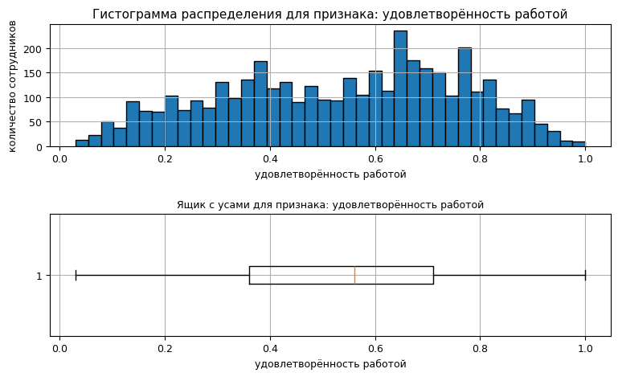

|  | job_satisfaction_rate |
| --- | --- |
| count | 4000.000000 |
| mean | 0.533995 |
| std | 0.225327 |
| min | 0.030000 |
| 25% | 0.360000 |
| 50% | 0.560000 |
| 75% | 0.710000 |
| max | 1.000000 |

```python
show_num_feature(satisfaction, 'job_satisfaction_rate', 'удовлетворённость работой', bins=40)
```

Значений, выходящих за пределы допустимого интервала нет. Распределение похоже на нечто среднее, между нормальным и равномерным.

#### Отдел, в котором работает сотрудник (dept)

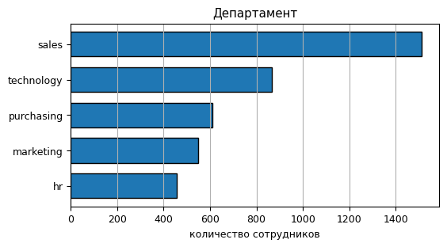

```python
show_cat_feature(satisfaction, 'dept', 'Департамент')
```

Признак имеет 5 возможных значений. Скрытых дубликатов не обраружено.

#### Уровень занимаемой должности (level)

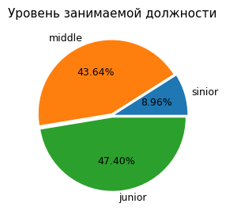

```python
show_cat_feature(satisfaction, 'level', 'Уровень занимаемой должности')
```

Признак имеет 3 возможных значения. Скрытых дубликатов не обраружено.

#### Уровень загруженности сотрудника (workload)

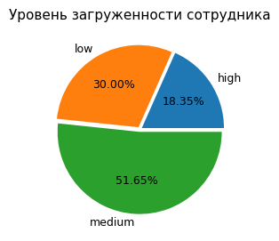

```python
show_cat_feature(satisfaction, 'workload', 'Уровень загруженности сотрудника')
```

Признак имеет 3 возможных значения. Скрытых дубликатов не обраружено.

#### Длительность работы в компании (employment_years)

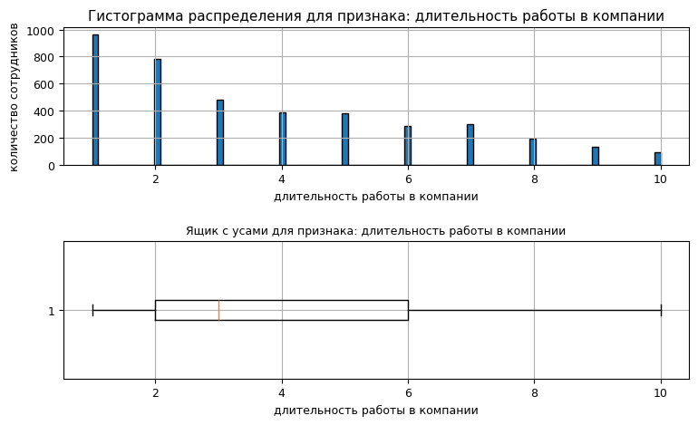

|  | employment_years |
| --- | --- |
| count | 4000.000000 |
| mean | 3.718500 |
| std | 2.542513 |
| min | 1.000000 |
| 25% | 2.000000 |
| 50% | 3.000000 |
| 75% | 6.000000 |
| max | 10.000000 |

```python
show_num_feature(satisfaction, 'employment_years', 'длительность работы в компании')
```

Аномальных значений нет. Новичков в компании больше, чем сотрудников, которые работают давно.

#### Было ли повышение за последний год (last_year_promo)

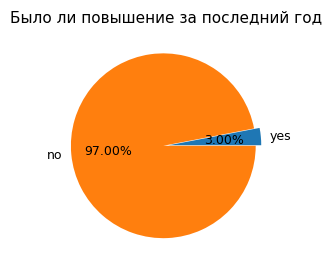

```python
show_cat_feature(satisfaction, 'last_year_promo', 'Было ли повышение за последний год')
```

Скрытых дубликатов нет. Признак бинарный. Есть большой дисбаланс классов - за последний год повышение было всего лишь у 3% сотрудников.

#### Нарушал ли сотрудник трудовой договор за последний год (last_year_violations)

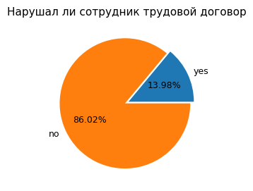

```python
show_cat_feature(satisfaction, 'last_year_violations', 'Нарушал ли сотрудник трудовой договор')
```

Скрытых дубликатов нет. Признак бинарный. Есть небольшой дисбаланс классов - за последний год трудовой договор нарушали 14% сотрудников.

#### Оценка качества работы сотрудника (supervisor_evaluation)

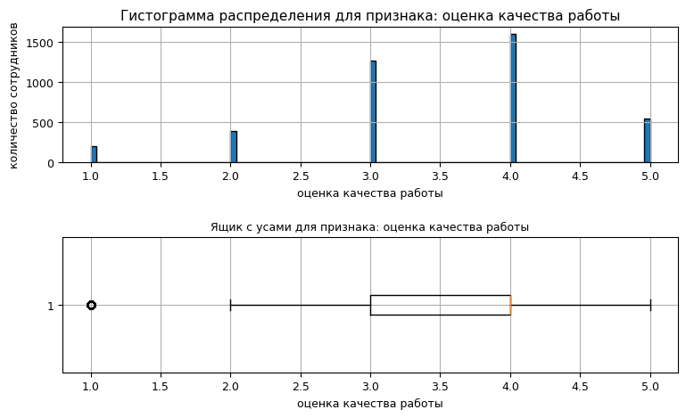

|  | supervisor_evaluation |
| --- | --- |
| count | 4000.000000 |
| mean | 3.476500 |
| std | 1.008812 |
| min | 1.000000 |
| 25% | 3.000000 |
| 50% | 4.000000 |
| 75% | 4.000000 |
| max | 5.000000 |

```python
show_num_feature(satisfaction, 'supervisor_evaluation', 'оценка качества работы')
```

По факту признак ранговый. Имеет имеет 5 возможных значений. Распределение похоже на левостороннее.

#### Зарплата (salary)

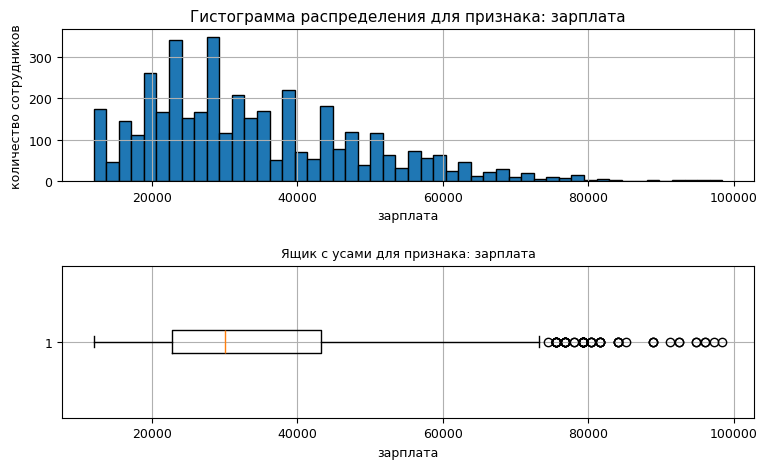

|  | salary |
| --- | --- |
| count | 4000.000000 |
| mean | 33926.700000 |
| std | 14900.703838 |
| min | 12000.000000 |
| 25% | 22800.000000 |
| 50% | 30000.000000 |
| 75% | 43200.000000 |
| max | 98400.000000 |

```python
show_num_feature(satisfaction, 'salary', 'зарплата', bins=50)
```

Распределение похоже на распределение Пуассона. Сотрудников с большой зарплатой гораздо меньше. Максимальная зарплата больше минимальной чуть менее чем в 10 раз. Всё перечисленное соответствет реальности, поэтому можно считаль, что аномальных значений нет.

#### Итоги исследовательского анализа

Было проанализировано распределение всех признаков. Скрытых дубликатов в категориальных признаках не выявлено. Аномальных значений не выявлено.

### Корреляционный анализ

Построим корреляционную матрицу phik для анализа нелинейных зависимостей.

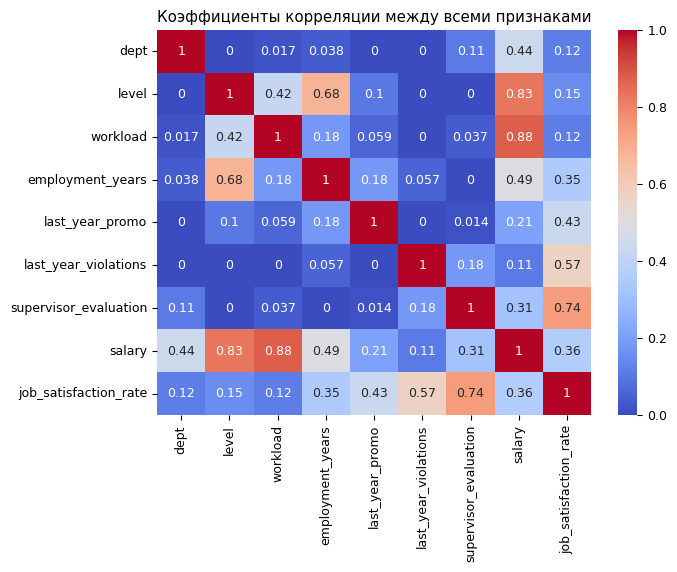

```python
num_col_names = ['employment_years', 'salary', 'job_satisfaction_rate']
corr_matrix_phik = satisfaction.drop(columns='id').phik_matrix(interval_cols=num_col_names, bins=50)
plt.figure(figsize=(7, 5))
sns.heatmap(corr_matrix_phik, annot=True, cmap='coolwarm')
plt.title('Коэффициенты корреляции между всеми признаками')
plt.show()
```

**Выводы из корреляционного анализа:**

1. Сильнее всего целевой признак (job_satisfaction_rate) коррелирует с оценкой качества работы сотрудника (supervisor_evaluation), коэффициент корреляции 0.74.
2. Меньше всего целевой признак зависит от департамента, уровня должности и загруженности (dept, level, workload), коэффициенты корреляции 0.12 - 0.15.
3. Наблюдается высокая корреляция между следующими входящими признаками (возможно, их не стоит использовать для обучения модели, есть смысл протестировать все варианты):
   - salary и workload - 0.88
   - salary и level - 0.83

### Созание пайплайна. Подбор параметров. Выбор лучшей модели

#### Выбор метрики для оценки модели

Для оценки модели была выбрана ментрика SMAPE, которая рассчитывается по формуле:

$$ SMAPE = \frac{100}{n} \sum_{i=1}^n \frac{|y_i - \hat{y}_i|}{\frac{(|y_i| + |\hat{y}_i|)}{2}} , $$

где:

- $ y_i $ - фактическое значение целевого признака
- $ \hat{y}_i $ - предсказанне значение целевого признака
- $ n $ - количество объектов в выборке

Критерий успеха: $ SMAPE \le 15 $ на тестовой выборке.

Данная метрика создаётся в отдельном классе Scores.

#### Создание тренировочной и тестовой выборок (повторная проверка на наличие дубликатов)

Определим id как индексы, и заново проверим датафрейм на наличие дубликатов. (Могут быть разные пользователи с полностью идентичными показателями.)

```python
satisfaction = satisfaction.set_index('id')
print(f'Всего дубликатов без учёта id: {satisfaction.duplicated().sum()}')
print('Примеры дублирующихся строк:')
satisfaction[satisfaction.duplicated()].sample(3)
```

```
Всего дубликатов без учёта id: 245
Примеры дублирующихся строк:
```

| id | dept | level | workload | employment_years | last_year_promo | last_year_violations | supervisor_evaluation | salary | job_satisfaction_rate |
| --- | --- | --- | --- | --- | --- | --- | --- | --- | --- |
| 409882 | purchasing | junior | low | 1 | no | no | 4 | 15600 | 0.65 |
| 849565 | technology | junior | high | 2 | no | no | 4 | 46800 | 0.79 |
| 332068 | marketing | junior | low | 2 | no | no | 4 | 20400 | 0.75 |

Удалим эти дубликаты из тренировочной выборки, они не несут никакой пользы для обучения модели, а могут только навредить.

```python
satisfaction = satisfaction.drop_duplicates()
print(f'Всего дубликатов без учёта id: {satisfaction.duplicated().sum()}')
```

```
Всего дубликатов без учёта id: 0
```

Разделим датафрейм на целевой признак и входящие.

```python
# Создание тренировочной выборки
X_train = satisfaction.sort_values(by='id').drop(columns=['job_satisfaction_rate'])
y_train = satisfaction.sort_values(by='id')['job_satisfaction_rate'].to_frame()
print(f'Размер X_train: {X_train.shape}')
display(X_train.head(3))
print(f'Размер y_train: {y_train.shape}')
display(y_train.head(3))
```

```
Размер X_train: (3755, 8)
```

| id | dept | level | workload | employment_years | last_year_promo | last_year_violations | supervisor_evaluation | salary |
| --- | --- | --- | --- | --- | --- | --- | --- | --- |
| 100954 | purchasing | junior | low | 1 | no | no | 4 | 15600 |
| 101057 | sales | junior | low | 1 | no | yes | 4 | 19200 |
| 101074 | sales | junior | medium | 2 | no | no | 2 | 20400 |

```
Размер y_train: (3755, 1)
```

| id | job_satisfaction_rate |
| --- | --- |
| 100954 | 0.60 |
| 101057 | 0.45 |
| 101074 | 0.36 |

```python
# Создание тестовой выборки
X_test = test_satisfaction_x.set_index('id').sort_values(by='id')
y_test = test_satisfaction_y.set_index('id').sort_values(by='id')
print(f'Размер X_test: {X_test.shape}')
display(X_test.head(3))
print(f'Размер y_test: {y_test.shape}')
display(y_test.head(3))
```

```
Размер X_test: (2000, 8)
```

| id | dept | level | workload | employment_years | last_year_promo | last_year_violations | supervisor_evaluation | salary |
| --- | --- | --- | --- | --- | --- | --- | --- | --- |
| 100298 | hr | junior | low | 2 | no | no | 4 | 19200 |
| 100480 | marketing | junior | low | 4 | no | no | 4 | 16800 |
| 100503 | purchasing | middle | high | 5 | no | no | 4 | 55200 |

```
Размер y_test: (2000, 1)
```

| id | job_satisfaction_rate |
| --- | --- |
| 100298 | 0.80 |
| 100480 | 0.84 |
| 100503 | 0.79 |

#### Подбор лучших параметров, сравнение моделей

```python
# Создаём экземпляр класса, задаём необходимые данные и настройки, запускаем подбор
study = Study(X_train, y_train, X_test, y_test, reg_clas_flag='Regression', cv_num=10)
models_for_test_list = ['LinearRegression', 'Ridge', 'KNNRegressor', 'DecisionTreeRegressor', 'RandomForestRegressor', 'CatBoostRegressor']
study.set_models_list(models_for_test_list)
study.set_model_score('SMAPE')
study.set_trials_num(100)
study.set_show_trials_num(1)
study.run()
```

| LinearRegression | SMAPE | duration | drop_workload_flag | drop_level_flag | num_encoding | cat_encoding | fit_intercept |
| --- | --- | --- | --- | --- | --- | --- | --- |
| 1 | 24.945747 | 00:00:00.408213 | False | False | MinMaxScaler | OneHotEncoder | False |

| Ridge | SMAPE | duration | drop_workload_flag | drop_level_flag | num_encoding | cat_encoding | alpha | fit_intercept | solver |
| --- | --- | --- | --- | --- | --- | --- | --- | --- | --- |
| 1 | 25.027972 | 00:00:00.397418 | False | False | passthrough | OneHotEncoder | 1.727598 | True | cholesky |

| KNNRegressor | SMAPE | duration | drop_workload_flag | drop_level_flag | num_encoding | cat_encoding | algorithm | n_neighbors | weights |
| --- | --- | --- | --- | --- | --- | --- | --- | --- | --- |
| 1 | 16.107809 | 00:00:00.598672 | False | False | RobustScaler | OneHotEncoder | auto | 9 | distance |

| DecisionTreeRegressor | SMAPE | duration | drop_workload_flag | drop_level_flag | num_encoding | cat_encoding | criterion | max_depth | max_features | min_samples_split |
| --- | --- | --- | --- | --- | --- | --- | --- | --- | --- | --- |
| 1 | 14.840427 | 00:00:00.425297 | False | False | RobustScaler | OrdinalEncoder | squared_error | 17 | 11 | 9 |

| RandomForestRegressor | SMAPE | duration | drop_workload_flag | drop_level_flag | num_encoding | cat_encoding | criterion | max_depth | max_features |
| --- | --- | --- | --- | --- | --- | --- | --- | --- | --- |
| 1 | 13.427484 | 00:00:04.667026 | False | False | RobustScaler | OneHotEncoder | friedman_mse | 16 | 5 |

| CatBoostRegressor | SMAPE | duration | drop_workload_flag | drop_level_flag | num_encoding | cat_encoding | bagging_temperature | depth | embedding_dim | l2_leaf_reg | learning_rate | loss_function | random_strength | iterations |
| --- | --- | --- | --- | --- | --- | --- | --- | --- | --- | --- | --- | --- | --- | --- |
| 1 | 10.931093 | 00:01:56.649970 | False | False | StandardScaler | EmbeddingEncoder | 0.9296 | 6 | 15.0 | 0.086816 | 0.013134 | RMSE | 0.783904 | 3574 |

| models_best_results | model | SMAPE_cv | SMAPE_test |
| --- | --- | --- | --- |
| 1 | CatBoostRegressor | 10.931093 | 10.322597 |
| 2 | RandomForestRegressor | 13.427484 | 12.372859 |
| 3 | DecisionTreeRegressor | 14.840427 | 13.586431 |
| 4 | KNNRegressor | 16.107809 | 14.347945 |
| 5 | LinearRegression | 24.945747 | 23.597329 |
| 6 | Ridge | 25.027972 | 23.561608 |

**Вывод:** Из протестированных моделей, только деревья и KNN смогли преодолеть порог на тестовой выборке ($ SMAPE \leq 15% $). Лучшей моделью оказалась CatBoostRegressor.

#### Создаём и обучаем лучшую модель регрессии.

Создадим и обучим лучший пайплайн.

```python
# Сохраняем лучший словарь в глобальную переменную
best_pipe_regressor_from_optuna = study.best_piplines_dict['CatBoostRegressor']
```

```python
# Обучаем и считаем метрику
ms = MetricSmape()
y_pred = best_pipe_regressor_from_optuna.predict(X_test)
smape_test = abs(ms.smape(best_pipe_regressor_from_optuna, X_test, y_test))
print(f'Модель CatBoostRegressor, метрика smape на тестовой выборке: {smape_test}')
```

```
Модель CatBoostRegressor, метрика smape на тестовой выборке: 10.32259749680086
```

Поскольку, поиск работает достаточно долго, для экономии времени при работе над второй частью проекта, создадим модель вручную.

```python
# Создаём эеземпляр класса с метрикой
ms = MetricSmape()

# Создаём пайплайн по заданным параметрам
def create_regressor_model(encoder):
    cat_pipe = ImbPipeline(
        [
            ('simple_imputer_before_cat', SimpleImputer(missing_values=np.nan, strategy='most_frequent')),
            ('cat_encoder', encoder),
            ('simple_imputer_after_cat', SimpleImputer(missing_values=np.nan, strategy='most_frequent'))
        ]
    )

    num_pipe = ImbPipeline(
        [
            ('simple_imputer_before_num', SimpleImputer(missing_values=np.nan, strategy='median')),
            ('num_encoder', MinMaxScaler())
        ]
    )

    preprocessor = ColumnTransformer(
        [
            ('cat', cat_pipe, make_column_selector(dtype_include=object)),
            ('num', num_pipe, make_column_selector(dtype_include=np.number))
        ],
        remainder='passthrough'
    )

    pipe_regressor = ImbPipeline(
        [
            ('preprocessor', preprocessor),
            ('model', CatBoostRegressor(random_seed=RANDOM_STATE,
                                        iterations=1139,
                                        verbose=False,
                                        bagging_temperature=0.264570,
                                        depth=7,
                                        l2_leaf_reg=0.245743,
                                        learning_rate=0.030131,
                                        random_strength=0.323693))
        ]
    )

    return pipe_regressor

best_pipe_regressor = create_regressor_model(EmbeddingEncoder(embedding_dim=26,
                                                              handle_unknown='ignore',
                                                              random_state=RANDOM_STATE))
best_pipe_regressor_ohe = create_regressor_model(OneHotEncoder(drop='first',
                                                               handle_unknown='ignore'))

# Обучаем и повторно тестируем лучшую модель
best_pipe_regressor.fit(X_train, y_train)
y_pred = best_pipe_regressor.predict(X_test)
smape_test = abs(ms.smape(best_pipe_regressor, X_test, y_test))
print(f'Модель Catboost, метрика smape на тестовой выборке: {smape_test}')

# Обучаем и повторно тестируем лучшую модель
best_pipe_regressor_ohe.fit(X_train, y_train)
y_pred = best_pipe_regressor.predict(X_test)
smape_test = abs(ms.smape(best_pipe_regressor_ohe, X_test, y_test))
print(f'Модель Catboost c OHE-кодировщиком, метрика smape на тестовой выборке: {smape_test}')
```

```
Модель Catboost, метрика smape на тестовой выборке: 10.339533987467542
Модель Catboost c OHE-кодировщиком, метрика smape на тестовой выборке: 10.535388289855252
```

## Задача 2: Предсказание увольнения сотрудника из компании

### Загрузка данных, изучение общей информации о датафрейме

```python
# Создаём датафреймы из файлов
try:
    quit = pd.read_csv('datasets\\train_quit.csv')
    test_quit_x = pd.read_csv('datasets\\test_features.csv')
    test_quit_y = pd.read_csv('datasets\\test_target_quit.csv')
except:
    print('Данные не были загружены')
```

```python
print(quit.shape)
quit.head(3)
```

```
(4000, 10)
```

|  | id | dept | level | workload | employment_years | last_year_promo | last_year_violations | supervisor_evaluation | salary | quit |
| --- | --- | --- | --- | --- | --- | --- | --- | --- | --- | --- |
| 0 | 723290 | sales | middle | high | 2 | no | no | 4 | 54000 | no |
| 1 | 814010 | sales | junior | medium | 2 | no | no | 4 | 27600 | no |
| 2 | 155091 | purchasing | middle | medium | 5 | no | no | 1 | 37200 | no |

```python
print(test_quit_x.shape)
test_quit_x.head(3)
```

```
(2000, 9)
```

|  | id | dept | level | workload | employment_years | last_year_promo | last_year_violations | supervisor_evaluation | salary |
| --- | --- | --- | --- | --- | --- | --- | --- | --- | --- |
| 0 | 485046 | marketing | junior | medium | 2 | no | no | 5 | 28800 |
| 1 | 686555 | hr | junior | medium | 1 | no | no | 4 | 30000 |
| 2 | 467458 | sales | middle | low | 5 | no | no | 4 | 19200 |

```python
print(test_quit_y.shape)
test_quit_y.head(3)
```

```
(2000, 2)
```

|  | id | quit |
| --- | --- | --- |
| 0 | 999029 | yes |
| 1 | 372846 | no |
| 2 | 726767 | no |

**Итоги загрузки данных:** Данные были успешно загружены. Колонки соответствуют описанию.

### Предобработка данных

#### Обработка дубликатов

Проверим датафреймы на наличие дубликатов по id.

```python
print('Количество дубликатов по id:')
print('quit:', quit['id'].duplicated().sum())
print('test_quit_x:', test_quit_x['id'].duplicated().sum())
print('test_quit_y:', test_quit_y['id'].duplicated().sum())
```

```
Количество дубликатов по id:
quit: 0
test_quit_x: 0
test_quit_y: 0
```

**Итоги обработки дубликатов:** Дубликатов не обнаружено.

#### Обработка пропусков

Проверим датафреймы на наличие пропусков.

```python
quit.isna().sum()
```

```
id                       0
dept                     0
level                    0
workload                 0
employment_years         0
last_year_promo          0
last_year_violations     0
supervisor_evaluation    0
salary                   0
quit                     0
dtype: int64
```

В тренировочном датафрейме нет явных пропусков.

```python
test_quit_x.isna().sum()
```

```
id                       0
dept                     2
level                    1
workload                 0
employment_years         0
last_year_promo          0
last_year_violations     0
supervisor_evaluation    0
salary                   0
dtype: int64
```

```python
test_quit_x[test_quit_x['dept'].isna() | test_quit_x['level'].isna()]
```

|  | id | dept | level | workload | employment_years | last_year_promo | last_year_violations | supervisor_evaluation | salary |
| --- | --- | --- | --- | --- | --- | --- | --- | --- | --- |
| 191 | 609865 | NaN | junior | medium | 1 | no | no | 1 | 20400 |
| 312 | 471990 | sales | NaN | low | 1 | no | no | 3 | 12000 |
| 1196 | 832342 | NaN | junior | medium | 1 | no | no | 4 | 28800 |

В тестовом датавфрейме c входящими признаками есть 3 пропуска в категориалных колонках level и dept.

```python
test_quit_y.isna().sum()
```

```
id      0
quit    0
dtype: int64
```

В тестовом датафрейме c целевым признаком пропусков нет.

#### Проверка датафреймов на соответствие друг другу

Проверим, что в тестовых датафреймах с входящими признаками и с целевым признаком у пользователей одни и те же id.

```python
set(test_quit_x['id']) == set(test_quit_y['id'])
```

```
True
```

В датафреймах test_quit_x и test_quit_y одни и те же id, а значит датафреймы соответствуют друг другу.

Проверим, что в тренировочном и тестовом датафреймах разные id.

```python
c = 0
for employee in test_quit_x['id'].tolist():
    if employee in (quit['id'].tolist()):
        c += 1
print(c)
```

```
0
```

### Исследовательский анализ данных

#### Анеализ целевого признака - уволился пользователь или нет (quit)

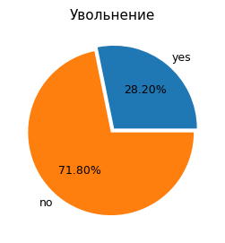

```python
show_cat_feature(quit, 'quit', 'Увольнение')
```

Есть дисбаланс классов (уволилось 28% сотрудников, осталось 72%). При создании пайплайна, нужно использовать семплирование.

#### Анализ входящих признаков

Входные признаки были проанализированы, при выполнении предыдущей задачи. В данном случае, для обучения модели будет использована другая выборка, но набор входящих признаков и их структура полностью совпадают, поэтому в повторном анализе нет необходимости.

#### Составление портрета «уволившегося сотрудника».

##### Доля уволившихся в зависимости от отдела

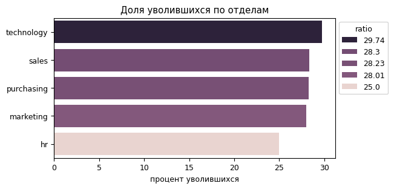

| dept | no | yes | all | ratio |
| --- | --- | --- | --- | --- |
| technology | 652 | 276 | 928 | 29.74 |
| sales | 1031 | 407 | 1438 | 28.30 |
| purchasing | 422 | 166 | 588 | 28.23 |
| marketing | 419 | 163 | 582 | 28.01 |
| hr | 348 | 116 | 464 | 25.00 |

```python
show_pivot(quit, 'dept', 'Доля уволившихся по отделам')
```

В целом, во всех отделах примерно одинаковая доля уволившихся, от 25 до 30%. В отделе technology доля уволившихся чуть выше среднего, а в отделе hr чуть ниже.

##### Доля уволившихся в зависимости от уровня должности

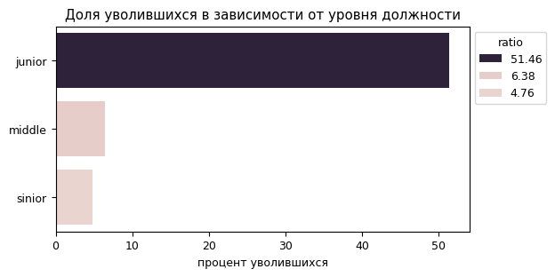

| level | no | yes | all | ratio |
| --- | --- | --- | --- | --- |
| junior | 946 | 1003 | 1949 | 51.46 |
| middle | 1586 | 108 | 1694 | 6.38 |
| sinior | 340 | 17 | 357 | 4.76 |

```python
show_pivot(quit, 'level', 'Доля уволившихся в зависимости от уровня должности')
```

Чем выше занимаемая должность - тем меньше вероятность увольнения.

##### Доля уволившихся в зависимости от нагрузки

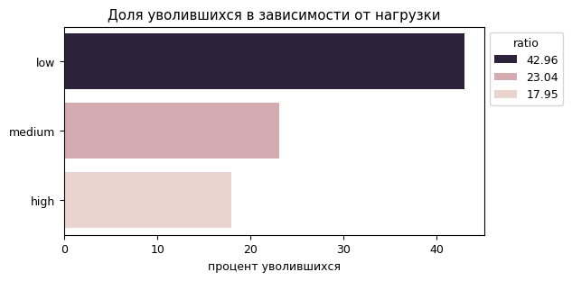

| workload | no | yes | all | ratio |
| --- | --- | --- | --- | --- |
| low | 689 | 519 | 1208 | 42.96 |
| medium | 1630 | 488 | 2118 | 23.04 |
| high | 553 | 121 | 674 | 17.95 |

```python
show_pivot(quit, 'workload', 'Доля уволившихся в зависимости от нагрузки')
```

Чем меньше рабочая нагрузка, тем выше вероятность увольнения. Нагрузите сотрудника работой, и у него не останется времени на мысли о смене работы!

##### Доля уволившихся в зависимости от стажа

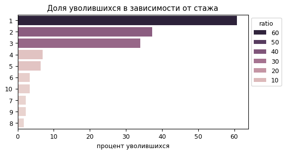

| employment_years | no | yes | all | ratio |
| --- | --- | --- | --- | --- |
| 1 | 386 | 599 | 985 | 60.81 |
| 2 | 487 | 290 | 777 | 37.32 |
| 3 | 316 | 163 | 479 | 34.03 |
| 4 | 366 | 27 | 393 | 6.87 |
| 5 | 339 | 23 | 362 | 6.35 |
| 6 | 286 | 10 | 296 | 3.38 |
| 10 | 87 | 3 | 90 | 3.33 |
| 7 | 301 | 7 | 308 | 2.27 |
| 9 | 133 | 3 | 136 | 2.21 |
| 8 | 171 | 3 | 174 | 1.72 |

```python
show_pivot(quit, 'employment_years', 'Доля уволившихся в зависимости от стажа')
```

Самая большая доля уволившихся среди сотрудников, которые не проработали в компании более 3-х лет. Из них больше всего людей увольняются в первый год работы.

##### Доля уволившихся в зависимости от того, было повышение за последний год или нет

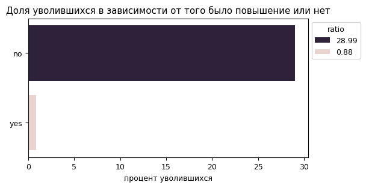

| last_year_promo | no | yes | all | ratio |
| --- | --- | --- | --- | --- |
| no | 2760 | 1127 | 3887 | 28.99 |
| yes | 112 | 1 | 113 | 0.88 |

```python
show_pivot(quit, 'last_year_promo', 'Доля уволившихся в зависимости от того было повышение или нет')
```

Доля уволившихся среди сотрудников, у которых недавно было повышение очень низкая.

##### Доля уволившихся в зависимости от оценки качества работы

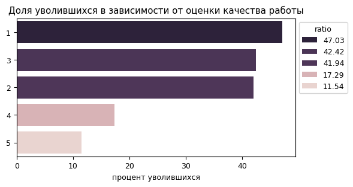

| supervisor_evaluation | no | yes | all | ratio |
| --- | --- | --- | --- | --- |
| 1 | 107 | 95 | 202 | 47.03 |
| 3 | 710 | 523 | 1233 | 42.42 |
| 2 | 227 | 164 | 391 | 41.94 |
| 4 | 1368 | 286 | 1654 | 17.29 |
| 5 | 460 | 60 | 520 | 11.54 |

```python
show_pivot(quit, 'supervisor_evaluation', 'Доля уволившихся в зависимости от оценки качества работы')
```

Чем выше оценивается качество работы сотрудника, тем менее вероятно, что он уволится.

##### Доля уволившихся в зависимости от нарушений трудового договора

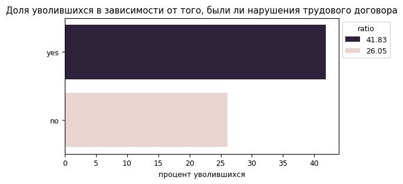

| last_year_violations | no | yes | all | ratio |
| --- | --- | --- | --- | --- |
| yes | 317 | 228 | 545 | 41.83 |
| no | 2555 | 900 | 3455 | 26.05 |

```python
show_pivot(quit, 'last_year_violations', 'Доля уволившихся в зависимости от того, были ли нарушения трудового договора')
```

Среди сотрудников с нарушениями трудового договора, доля увольнений ощутимо выше, чем среди сотрудников без нарушений.

##### Зависимость средней зарплаты в от увольнения

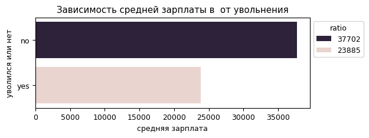

```python
pivot = quit.pivot_table(index='quit', values='salary', aggfunc='mean')
pivot['salary'] = pivot['salary'].astype('int')
plt.rcParams['figure.figsize'] = (6, 2)
plt.rcParams.update({'font.size': 9})
sns.barplot(pivot, x='salary', y='quit', hue='salary')
handles, labels = plt.gca().get_legend_handles_labels()
plt.legend(reversed(handles), reversed(labels), title='ratio',bbox_to_anchor=(1, 1))
plt.title('Зависимость средней зарплаты в  от увольнения')
plt.xlabel('средняя зарплата')
plt.ylabel('уволился или нет')
plt.show()
```

##### Итоговый портрет уволившегося сотрудника

1. сотрудник раболтает в компании не более 3-х лет
2. сотрудник занимает должность junior
3. у сотрудника низкий уровень загруженности работой
4. у сотрудника не было повышения
5. работу сотрудника оценивают достаточно низко (не более 3-х по пятибалльной шкале)
6. у сотрудника были нарушения трудового договора
7. зарплата сотрудника ниже среднего
8. вероятность увольнения не зависит от отдела, в котором работает сотрудник

#### Добавимление предсказанного признака удовлетворённости сотрудника работой в датафрейм

Предскажем показатель удовлетворённости работой, с помощью лучшей модели, разработанной в первой части.

```python
satisfaction_pred_train = best_pipe_regressor.predict(quit)
quit['satisfaction'] = satisfaction_pred_train
print('quit_train:')
display(quit.head(3))
print()

print('quit_test:')
satisfaction_pred_test = best_pipe_regressor.predict(test_quit_x)
test_quit_x['satisfaction'] = satisfaction_pred_test
display(quit.head(3))
```

```
quit_train:
```

|  | id | dept | level | workload | employment_years | last_year_promo | last_year_violations | supervisor_evaluation | salary | quit | satisfaction |
| --- | --- | --- | --- | --- | --- | --- | --- | --- | --- | --- | --- |
| 0 | 723290 | sales | middle | high | 2 | no | no | 4 | 54000 | no | 0.653930 |
| 1 | 814010 | sales | junior | medium | 2 | no | no | 4 | 27600 | no | 0.837275 |
| 2 | 155091 | purchasing | middle | medium | 5 | no | no | 1 | 37200 | no | 0.326494 |

```
quit_test:
```

|  | id | dept | level | workload | employment_years | last_year_promo | last_year_violations | supervisor_evaluation | salary | quit | satisfaction |
| --- | --- | --- | --- | --- | --- | --- | --- | --- | --- | --- | --- |
| 0 | 723290 | sales | middle | high | 2 | no | no | 4 | 54000 | no | 0.653930 |
| 1 | 814010 | sales | junior | medium | 2 | no | no | 4 | 27600 | no | 0.837275 |
| 2 | 155091 | purchasing | middle | medium | 5 | no | no | 1 | 37200 | no | 0.326494 |

#### Анализ зависимости уровня удовлетворённости сотрудника работой от фактического увольнения

Построим гистограммы распределения уровня удовлетворённости для уволившихся и не уволившихся сотрудников.

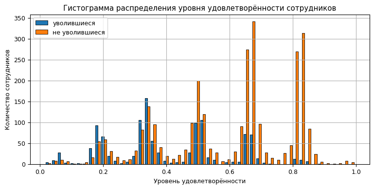

```
Средний уровень удовлетворённости не уволившихся сотрудников: 59.22%
Средний уровень удовлетворённости уволившихся сотрудников: 39.90%
```

```python
quit_yes = quit[quit['quit'] == 'yes']
quit_no = quit[quit['quit'] == 'no']

fig, ax = plt.subplots(figsize=(9, 4))
ax.hist([quit_yes['satisfaction'], quit_no['satisfaction']],
        linewidth=0.6,
        edgecolor='k',
        bins=50,
        label=['уволившиеся', 'не уволившиеся'])
ax.set(title='Гистограмма распределения уровня удовлетворённости сотрудников',
       xlabel='Уровень удовлетворённости',
       ylabel='Количество сотрудников')
ax.legend()
ax.grid()
plt.show()

print(f"Средний уровень удовлетворённости не уволившихся сотрудников: {quit_no['satisfaction'].mean():.2%}")
print(f"Средний уровень удовлетворённости уволившихся сотрудников: {quit_yes['satisfaction'].mean():.2%}")
```

**Нулевая гипотеза:** У уволившихся и у не уволившихся сотрудников одинаковый уровень удовлетворённости работой.

**Альтернативная гипотеза:** Не уволившиеся сотрудники удовлетворены работой больше, чем не уволившиеся.

```python
# Задаём минимальную вероятность получить такую выборку, при условии, что гипотеза верна
alpha = 0.01
# Передаём в метод имеющиеся выборки и необходимые настройки
results = st.ttest_ind(quit_no['satisfaction'], quit_yes['satisfaction'],
                       equal_var=False,
                       alternative='greater')
# Выводим на экран p-значение
print('p-значение:', results.pvalue)
# Сравниваем p-значение с alpha и делаем вывод
if results.pvalue < alpha:
    print('Отвергаем нулевую гипотезу')
else:
    print('Не отвергаем нулевую гипотезу')
```

```
p-значение: 2.4192827253155234e-159
Отвергаем нулевую гипотезу
```

**Вывод:** Гипотеза подтвердилась: Уволившиеся сотрудники всреднем удовлетворены работой меньше, чем не уволившиеся.

### Корреляционный анализ данных

Построим корреляционную матрицу phik для анализа нелинейных зависимостей.

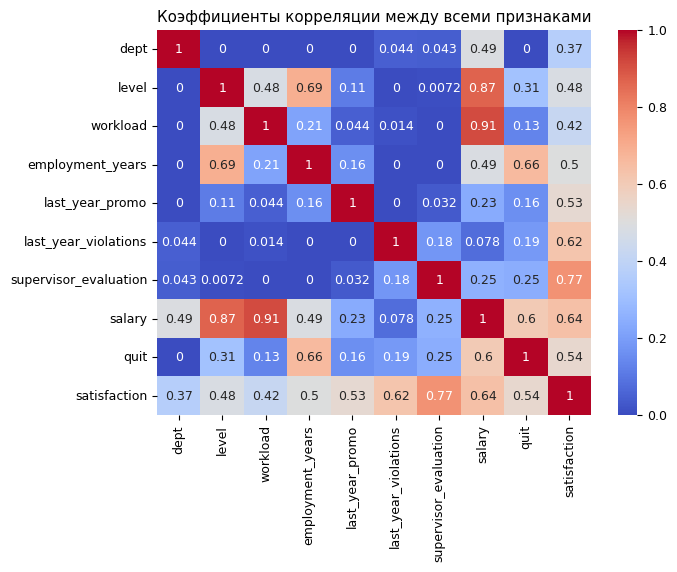

```python
num_col_names = ['salary', 'satisfaction']
corr_matrix_phik = quit.drop(columns='id').phik_matrix(interval_cols=num_col_names, bins=50)
plt.figure(figsize=(7, 5))
sns.heatmap(corr_matrix_phik, annot=True, cmap='coolwarm')
plt.title('Коэффициенты корреляции между всеми признаками')
plt.show()
```

### Созание пайплайна. Подбор параметров. Выбор лучшей модели

#### Выбор метрики для оценки модели

Метрика оценки качества в этой задаче ROC-AUC.

Критерий успеха: $ ROC-AUC \geq 0.91 $ на тестовой выборке.

#### Создание тренировочной и тестовой выборок (повторная проверка на наличие дубликатов)

Определим id как индексы, и заново проверим датафрейм на наличие дубликатов. (Могут быть разные пользователи с полностью идентичными показателями.)

```python
quit = quit.set_index('id')
print(f'Всего дубликатов без учёта id: {quit.duplicated().sum()}')
print('Примеры дублирующихся строк:')
quit[quit.duplicated()].sample(3)
```

```
Всего дубликатов без учёта id: 1413
Примеры дублирующихся строк:
```

| id | dept | level | workload | employment_years | last_year_promo | last_year_violations | supervisor_evaluation | salary | quit | satisfaction |
| --- | --- | --- | --- | --- | --- | --- | --- | --- | --- | --- |
| 803491 | technology | junior | medium | 2 | no | no | 4 | 31200 | no | 0.810607 |
| 782580 | purchasing | junior | low | 1 | no | no | 1 | 15600 | yes | 0.317593 |
| 740380 | hr | junior | medium | 1 | no | no | 4 | 26400 | no | 0.643662 |

Удалим эти дубликаты из тренировочной выборки, они не несут никакой пользы для обучения модели, а могут только навредить.

```python
quit = quit.drop_duplicates()
print(f'Всего дубликатов без учёта id: {quit.duplicated().sum()}')
```

```
Всего дубликатов без учёта id: 0
```

Разделим датафрейм на целевой признак и входящие, удаляем признак dept, который не коррелирует с целевым.

```python
# Создание тренировочной выборки
X_train_quit = quit.sort_values(by='id').drop(columns=['quit'])
y_train_quit = quit.sort_values(by='id')['quit'].to_frame()
X_test_quit = test_quit_x.set_index('id').sort_values(by='id')
y_test_quit = test_quit_y.set_index('id').sort_values(by='id')

# Удаляем из датафреймов признак, который не коррелирует с целевым
X_train_quit = X_train_quit.drop(columns='dept')
X_test_quit = X_test_quit.drop(columns='dept')

# Выводим на экран для проверки
print(f'Размер X_train_quit: {X_train_quit.shape}')
display(X_train_quit.head(3))
print()
print(f'Размер y_train_quit: {y_train_quit.shape}')
display(y_train_quit.head(3))
print()
print(f'Размер X_test_quit: {X_test_quit.shape}')
display(X_test_quit.head(3))
print()
print(f'Размер y_test_quit: {y_test_quit.shape}')
display(y_test_quit.head(3))
```

```
Размер X_train_quit: (2587, 8)
```

| id | level | workload | employment_years | last_year_promo | last_year_violations | supervisor_evaluation | salary | satisfaction |
| --- | --- | --- | --- | --- | --- | --- | --- | --- |
| 100222 | junior | medium | 3 | no | no | 2 | 20400 | 0.339840 |
| 100459 | junior | medium | 3 | no | no | 3 | 21600 | 0.338360 |
| 100858 | junior | medium | 2 | no | no | 4 | 25200 | 0.835048 |

```
Размер y_train_quit: (2587, 1)
```

| id | quit |
| --- | --- |
| 100222 | yes |
| 100459 | yes |
| 100858 | yes |

```
Размер X_test_quit: (2000, 8)
```

| id | level | workload | employment_years | last_year_promo | last_year_violations | supervisor_evaluation | salary | satisfaction |
| --- | --- | --- | --- | --- | --- | --- | --- | --- |
| 100298 | junior | low | 2 | no | no | 4 | 19200 | 0.828756 |
| 100480 | junior | low | 4 | no | no | 4 | 16800 | 0.826381 |
| 100503 | middle | high | 5 | no | no | 4 | 55200 | 0.825770 |

```
Размер y_test_quit: (2000, 1)
```

| id | quit |
| --- | --- |
| 100298 | no |
| 100480 | no |
| 100503 | no |

#### Кодирование целевого признака

```python
target_encoder_class = TargetEncoderClass()
y_train_quit = target_encoder_class.encoding_target_train(y_train_quit)
```

```
y_train_quit до кодировапния целевого признака:
```

| id | quit |
| --- | --- |
| 980648 | yes |
| 680308 | no |
| 610575 | no |

```
y_train_quit после кодирования целевого признака:
```

| id | quit |
| --- | --- |
| 980648 | 1 |
| 680308 | 0 |
| 610575 | 0 |

```python
y_test_quit = target_encoder_class.encoding_target_test(y_test_quit)
```

```
y_test_quit до кодировапния целевого признака:
```

| id | quit |
| --- | --- |
| 372661 | no |
| 190736 | no |
| 188280 | no |

```
y_test_quit после кодирования целевого признака:
```

| id | quit |
| --- | --- |
| 372661 | 0 |
| 190736 | 0 |
| 188280 | 0 |

#### Подбор лучших параметров, сравнение моделей

```python
# Создаём экземпляр класса, задаём необходимые данные и настройки, запускаем подбор
study = Study(X_train_quit, y_train_quit, X_test_quit, y_test_quit, reg_clas_flag='Classifier', cv_num=10)
models_for_test_list = ['LogisticRegression', 'KNNClassifier', 'SVC', 'DecisionTreeClassifier', 'RandomForestClassifier', 'CatBoostClassifier']
study.set_models_list(models_for_test_list)
study.set_model_score('roc_auc')
study.set_trials_num(100)
study.set_show_trials_num(1)
study.run()
```

| LogisticRegression | roc_auc | duration | drop_workload_flag | drop_level_flag | num_encoding | cat_encoding | C | sampler | solver_and_penalty |
| --- | --- | --- | --- | --- | --- | --- | --- | --- | --- |
| 1 | 0.912037 | 00:00:00.778440 | False | False | MinMaxScaler | OneHotEncoder | 5 | SMOTE | sag + None |

| KNNClassifier | roc_auc | duration | drop_workload_flag | drop_level_flag | num_encoding | cat_encoding | algorithm | n_neighbors | sampler | weights |
| --- | --- | --- | --- | --- | --- | --- | --- | --- | --- | --- |
| 1 | 0.913839 | 00:00:00.603180 | False | False | MinMaxScaler | OrdinalEncoder | kd_tree | 97 | SMOTE | uniform |

| SVC | roc_auc | duration | drop_workload_flag | drop_level_flag | num_encoding | cat_encoding | C | kernel | sampler |
| --- | --- | --- | --- | --- | --- | --- | --- | --- | --- |
| 1 | 0.91335 | 00:00:20.686676 | False | False | MinMaxScaler | OrdinalEncoder | 1 | rbf | ADASYN |

| DecisionTreeClassifier | roc_auc | duration | drop_workload_flag | drop_level_flag | num_encoding | cat_encoding | max_depth | max_features | sampler |
| --- | --- | --- | --- | --- | --- | --- | --- | --- | --- |
| 1 | 0.908652 | 00:00:00.345074 | False | False | passthrough | OrdinalEncoder | 4 | 5 | passthrough |

| RandomForestClassifier | roc_auc | duration | drop_workload_flag | drop_level_flag | num_encoding | cat_encoding | max_depth | max_features | n_estimators | sampler |
| --- | --- | --- | --- | --- | --- | --- | --- | --- | --- | --- |
| 1 | 0.919995 | 00:00:17.753500 | False | False | passthrough | OneHotEncoder | 6 | 2 | 974 | passthrough |

| CatBoostClassifier | roc_auc | duration | drop_workload_flag | drop_level_flag | num_encoding | cat_encoding | bagging_temperature | depth | embedding_dim | l2_leaf_reg | learning_rate | random_strength | sampler | iterations |
| --- | --- | --- | --- | --- | --- | --- | --- | --- | --- | --- | --- | --- | --- | --- |
| 1 | 0.927708 | 00:00:39.801171 | False | False | StandardScaler | EmbeddingEncoder | 0.848962 | 5 | 23.0 | 0.881403 | 0.038494 | 0.725034 | SMOTETomek | 184 |

| models_best_results | model | roc_auc_cv | roc_auc_test |
| --- | --- | --- | --- |
| 1 | CatBoostClassifier | 0.927708 | 0.931920 |
| 2 | RandomForestClassifier | 0.919995 | 0.926603 |
| 3 | KNNClassifier | 0.913839 | 0.914003 |
| 4 | SVC | 0.913350 | 0.915681 |
| 5 | LogisticRegression | 0.912037 | 0.917022 |
| 6 | DecisionTreeClassifier | 0.908652 | 0.911402 |

#### Создаём и обучаем лучшую модель классификации.

```python
classify_pipeline = study.best_piplines_dict['CatBoostClassifier']
y_pred = classify_pipeline.predict_proba(X_test_quit)[:,1]
rc = roc_auc_score(y_test_quit, y_pred)
print(f'Модель CatBoostClassifier, метрика roc-auc на тестовой выборке: {rc}')
```

```
Модель CatBoostClassifier, метрика roc-auc на тестовой выборке: 0.9319197090025484
```

Поскольку, поиск работает достаточно долго, для экономии времени при работе над заключительной частью проекта, создадим модель вручную. Для более наглядной интерпретации данных создадим ещё одну точно такую же модель, но с использованием OrdinalEncoder.

```python
# Определяем категории для OrdinalEncoder
category_order = {
    'workload': ['low', 'medium', 'high'],
    'level': ['junior', 'middle', 'sinior'],
    'last_year_promo': ['no', 'yes'],
    'last_year_violations': ['no', 'yes'],
}
cat_features = X_train_quit.select_dtypes(include=['object']).columns.tolist()
categories = [category_order[col] for col in cat_features]

def create_classifier_model(encoder):
    # Создаём пайплайн по заданным параметрам
    cat_pipe = ImbPipeline(
        [
            ('simple_imputer_before_encoder', SimpleImputer(missing_values=np.nan, strategy='most_frequent')),
            ('encoder', encoder),
            ('simple_imputer_after_encoder', SimpleImputer(missing_values=np.nan, strategy='most_frequent'))
        ]
    )

    num_pipe = ImbPipeline(
        [
            ('simple_imputer_before_scaler', SimpleImputer(missing_values=np.nan, strategy='median')),
            ('scaler', StandardScaler())
        ]
    )

    preprocessor = ColumnTransformer(
        [
            ('cat', cat_pipe, make_column_selector(dtype_include=object)),
            ('num', num_pipe, make_column_selector(dtype_include=np.number))
        ],
        remainder=Passthrough()
    )

    pipe_classifier = ImbPipeline(
        [
            ('preprocessor', preprocessor),
            ('sampler', RandomUnderSampler(random_state=RANDOM_STATE)),
            ('model', CatBoostClassifier(random_seed=RANDOM_STATE,
                                         iterations=198,
                                         verbose=False,
                                         bagging_temperature=0.489742,
                                         depth=2,
                                         l2_leaf_reg=0.746038,
                                         learning_rate=0.094673,
                                         random_strength=0.677138))
        ]
    )

    return pipe_classifier

# Обучаем пайплайны с разными кодировщиками
best_pipe_classifier = create_classifier_model(EmbeddingEncoder(embedding_dim=37,
                                                                handle_unknown='ignore',
                                                                random_state=RANDOM_STATE))
best_pipe_classifier_ord = create_classifier_model(OrdinalEncoder(categories=categories,
                                                                  handle_unknown='use_encoded_value',
                                                                  unknown_value=-1))

# Обучаем и повторно тестируем лучшую модель
best_pipe_classifier.fit(X_train_quit, y_train_quit)
y_pred_proba = best_pipe_classifier.predict_proba(X_test_quit)[:,1]
auc_test = roc_auc_score(y_test_quit, y_pred_proba)
print(f'Модель catboost, метрика roc-auc на тестовой выборке: {auc_test}')

# Обучаем и повторно тестируем лучшую модель, но с OrdinalEncoder
best_pipe_classifier_ord.fit(X_train_quit, y_train_quit)
y_pred_proba_ord = best_pipe_classifier_ord.predict_proba(X_test_quit)[:,1]
auc_test_ord = roc_auc_score(y_test_quit, y_pred_proba_ord)
print(f'Модель catboost_ord, метрика roc-auc на тестовой выборке: {auc_test_ord}')
```

```
Модель catboost, метрика roc-auc на тестовой выборке: 0.932268515774709
Модель catboost_ord, метрика roc-auc на тестовой выборке: 0.9308726713289477
```

## Анализ лучшей модели

### Создание экземпляра класса ShapShow

Для интерпретации модели создадим объект, заранее написанного класса, для просмотра shap-графиков.

```python
# Создаём экземпляр класса ShapKNN, для построения графиков
shap_show = ShapShow(best_pipe_classifier, X_train_quit, y_train_quit)
shap_show_ord = ShapShow(best_pipe_classifier_ord, X_train_quit, y_train_quit)
```

### Столпчатая диаграмма и «пчелиный рой» для модели, использовавшей EmbeddingEncoder

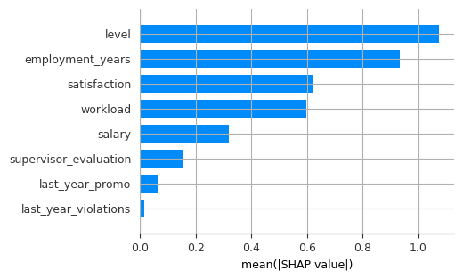

```python
shap_show.show_barplot()
```

Для понимания того, как именно входные признаки влияют на итоговые предсказания модели, посмотрим график пчелиного роя.

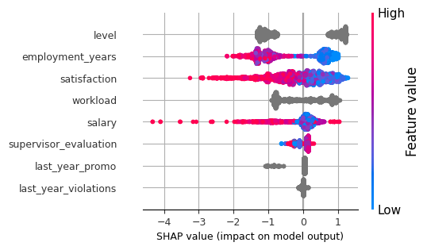

```python
shap_show.show_summary_plot()
```

Данный график не даёт полной информации о категориальных признаках, которые были закодированы с помощью EmbeddingEncoder, поэтому построим графики для модели, использовавшей OrdinalEncoder. Благодаря тому, что категории для OrdinalEncoder были заданы вручную, а все признаки, на основании которых делались предсказания для классификации, по факту являются ранговыми, мы можем интерпретировать эту модель.

### Столпчатая диаграмма и «пчелиный рой» для модели, использовавшей OrdinalEncoder

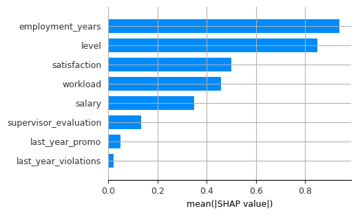

```python
shap_show_ord.show_barplot()
```

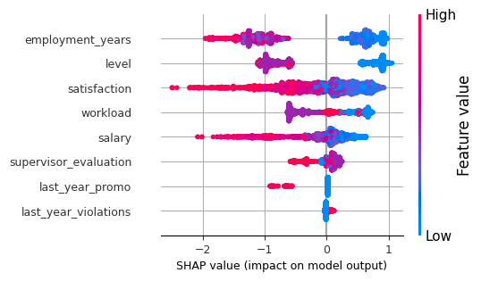

```python
shap_show_ord.show_summary_plot()
```

### Матрица ошибок

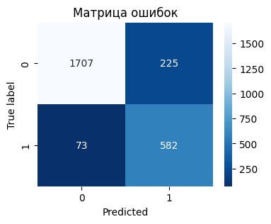

```
accuracy = 0.8848
precision = 0.7212
recall = 0.8885
```

```python
shap_show.show_confusion_matrix()
```

Ошибок типа False Positive больше, чем False Negative.

### Кривая roc-auc

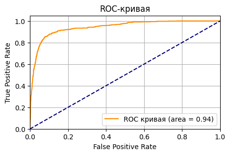

```python
shap_show.show_roc_curve()
```

Для первичной оценки качества моделей была выбрана метрика ROC-AUC (значение площади под ROC-кривой). Максимальная площадь под кривой позволит нам быть максимально гибкими в выборе порогового значения. Для этого нужно подобрать оптимальную точку на ROC-кривой.

### График зависимости ошибок от порогового значения

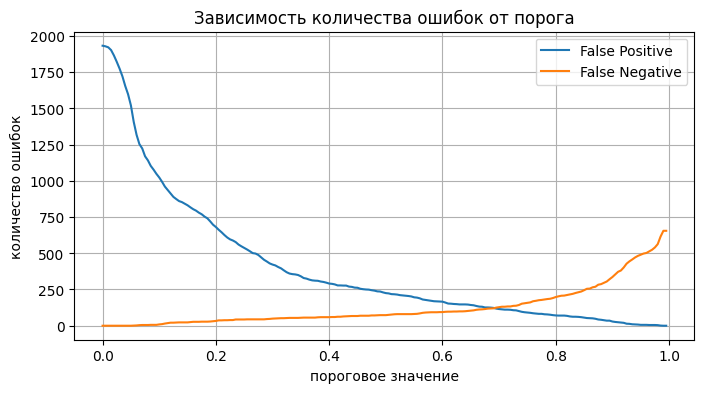

```python
shap_show.show_mistakes_threshold_plot()
```

Более наглядно картину можно посмотреть на графике зависимости ошибок False Positive и False Negative от порогового значения. В зависимости от того, насколько для компании важно вовремя заметить, что сотрудник собирается увольняться, и какие затраты она понесёт на его удержание, можно выставить оптимальное пороговое значение.

### Анализ предсказаний для пользователей по отдельности

Также мы можем проанализировать каждого пользователя по отдельности, для того что бы понять почему модель сделала именно такое предсказание для него. Прежде всего нас интересуют пользователи, с которыми модель ошиблась. Ошибки False Positive и False Negative будем рассматривать отдельно. (Также при необходимости мы можем отдельно посмотреть верные предсказания True Positive и True Negative).

Выведем на экран первыве 5 ошибок False Negative.

```python
shap_show.show_mistake_samples('FN', num_samples=5)
```

```
Всего ошибок типа FN: 73
```

|  | index | id | y_true | y_pred | y_pred_proba | mistake |
| --- | --- | --- | --- | --- | --- | --- |
| 0 | 1876 | 755131 | 1 | 0 | 0.050955 | FN |
| 1 | 176 | 158659 | 1 | 0 | 0.055032 | FN |
| 2 | 1180 | 514296 | 1 | 0 | 0.062300 | FN |
| 3 | 1088 | 490691 | 1 | 0 | 0.062728 | FN |
| 4 | 609 | 321175 | 1 | 0 | 0.068996 | FN |

Выведем на экран первыве 5 ошибок False Positive.

```python
shap_show.show_mistake_samples('FP', num_samples=5)
```

```
Всего ошибок типа FP: 225
```

|  | index | id | y_true | y_pred | y_pred_proba | mistake |
| --- | --- | --- | --- | --- | --- | --- |
| 0 | 1887 | 758734 | 0 | 1 | 0.985141 | FP |
| 1 | 680 | 346055 | 0 | 1 | 0.984313 | FP |
| 2 | 1208 | 526023 | 0 | 1 | 0.983556 | FP |
| 3 | 442 | 253498 | 0 | 1 | 0.981917 | FP |
| 4 | 1646 | 676623 | 0 | 1 | 0.979815 | FP |

|  | index | id | y_true | y_pred | y_pred_proba | mistake |
| --- | --- | --- | --- | --- | --- | --- |
| 629 | 629 | 327546 | 0 | 0 | 0.044333 | TN |

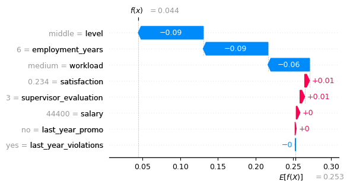

```python
shap_show.show_waterfall(629)
```

### Итоги анализа лучшей модели

Модель хорошо интерпретируется, зависимость предсказаний от входных признаков можно объяснить логически. Перед выпуском модели в продакшн нужно подобрать и установить оптимальное пороговое значение, в зависимости от средних расходов (доходов) компании в случае ошибок 1-го и 2-го рода и верных предсказаний.

## Общий вывод

**Задачи проекта**

**Результаты работы**

1. В ходе предобработки данных были выявлены редкие пропуски (менее 1%) в колонках dept и level.
1. Портрет «уволившегося сотрудника»:
   - сотрудник раболтает в компании не более 3-х лет
   - сотрудник занимает должность junior
   - у сотрудника низкий уровень загруженности работой
   - у сотрудника не было повышения
   - работу сотрудника оценивают достаточно низко (не более 3-х по пятибалльной шкале)
   - у сотрудника были нарушения трудового договора
   - зарплата сотрудника ниже среднего
   - вероятность увольнения не зависит от отдела, в котором работает сотрудник
1. Для оценки качества работы регрессии была создана специальная метрика SMAPE, которая рассчитывается по формуле:

$$ SMAPE = \frac{100}{n} \sum_{i=1}^n \frac{|y_i - \hat{y}_i|}{\frac{(|y_i| + |\hat{y}_i|)}{2}} $$